# R Workshop - Introduction and ecological applications

### 2D plots with three variables

In the first example, lets' create a plot for the relationship between two continous variables (Trophic level and body size) and a factor (species).

```r
TL_size <- read.csv ("TL_bodysize.csv", header=T, sep=";")
summary(TL_size)
```

```
 Trophic_level     Body_size                   Species
 Min.   :2.000   Min.   : 10   Cichla_monoculus    :10
 1st Qu.:2.475   1st Qu.: 50   Colossoma_macropomum:10
 Median :3.050   Median :100
 Mean   :3.085   Mean   :100
 3rd Qu.:3.625   3rd Qu.:150
 Max.   :4.300   Max.   :190
```

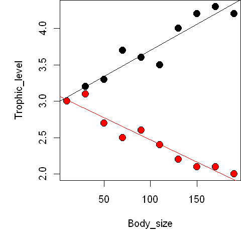

```r
par (mai=c(1,1,0,0))
plot (Trophic_level~Body_size,
      data= TL_size,
      pch=21, cex=1.5,
      bg = Species)
abline (lm(Trophic_level~Body_size,
           data= TL_size[TL_size$Species=="Cichla_monoculus",]),
       col="black") # adding tranding line to the plot
abline (lm(Trophic_level~Body_size,
           data= TL_size[TL_size$Species=="Colossoma_macropomum",]),
       col="red") # adding tranding line to the plot
```

Now, lets' create a plot for the relationship between two categorical variables (type of macrophyte, treatment) and one numerical variable (biomass). First, let's load the data.

```r
reserv <- read.table ("reservoir.txt",header=T)
head(reserv,3)
```

| Period | emergent_macrophytes | floating_macrophytes |
| --- | --- | --- |
| 1 | 11 | 16 |
| 1 | 12 | 16 |
| 1 | 16 | 16 |

We need to rearrange this dataframe in order to create a categorical variable describing the type of mycrophyte. Besides, the variable "period" (1=before experiment, 2=after experiment) needs to be converted into a categorical variable.

```r
reserv2 <- data.frame (Perc_macrophyte = c(reserv$emergent_macrophytes,reserv$floating_macrophytes),
                       Period = rep (reserv$Period,2),
                       Type = c(rep ("emergent_macrophytes", nrow(reserv)),
                                rep ("floating_macrophytes", nrow(reserv))
                                  ))

reserv2$Period <- factor (reserv2$Period)
levels (reserv2$Period) <- c("Before", "After") # Change name of the level of this categorical variable
summary (reserv2)
```

```
 Perc_macrophyte    Period                     Type
 Min.   : 5.00   Before:12   emergent_macrophytes:12
 1st Qu.:10.50   After :12   floating_macrophytes:12
 Median :13.50
 Mean   :13.58
 3rd Qu.:16.50
 Max.   :21.00
```

Now, we can use the ggplot2 library to create the plot.

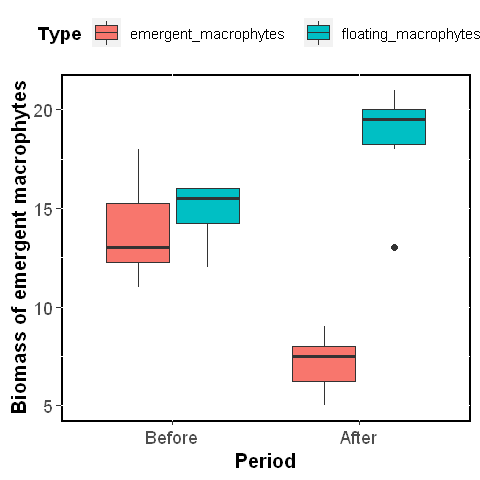

```r
require (ggplot2)
ggplot(reserv2, aes(x=Period, y=Perc_macrophyte, fill=Type)) + # Define data and variables
    geom_boxplot() + #Bow plot function
    ylab ("Biomass of emergent macrophytes") + xlab ("Period") + # Define axes titles
    theme (axis.text=element_text(size=11), # Font size of axis labels
           axis.title=element_text(size=12,face="bold"), # Font size of axis title.
           panel.background = element_rect(fill = "white", #Background color
                                colour = "black", # border line color
                                size = 1, linetype = "solid"),  #size and type of border line
           legend.position="top", #legend position
           legend.text=element_text(size=9), # size of legend text
           legend.title=element_text(size=11,face="bold") # size of legend title
          )
```

This type of relationship (2 categorical and one continuous variable) can also be represented using a line plot. First, we have to calculate average and standard deviation values for each combination of the exploratory variables.

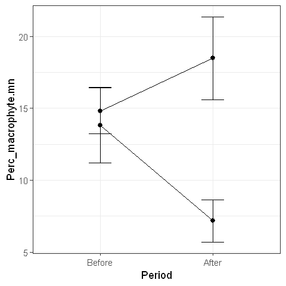

```r
Summ_reserv2<- as.matrix (
    aggregate (Perc_macrophyte ~ Period+Type, data= reserv2,
               FUN = function(x) c(mn = mean(x), sd = sd(x))))
Summ_reserv2 <- as.data.frame (Summ_reserv2)

Summ_reserv2<- within (Summ_reserv2,{
                       Perc_macrophyte.mn <- as.numeric (as.character(Perc_macrophyte.mn))
                       Perc_macrophyte.sd <- as.numeric (as.character(Perc_macrophyte.sd))
                       Period <- factor (Period, levels = c("Before", "After"))
                       }) #Make sure Perc_macrophyte.mn and Perc_macrophyte.sd are treated as numeric variables


ggplot (Summ_reserv2, aes (x=Period, y=Perc_macrophyte.mn, group=Type))+
               geom_line() + geom_point(size=2) +
               geom_errorbar(aes(ymin=Perc_macrophyte.mn-Perc_macrophyte.sd,
                                 ymax=Perc_macrophyte.mn+Perc_macrophyte.sd),
                             width=.2) +
               theme_bw ()
```

Finally, let's create a plot to show the relationship between three continuous (numerical) variables.

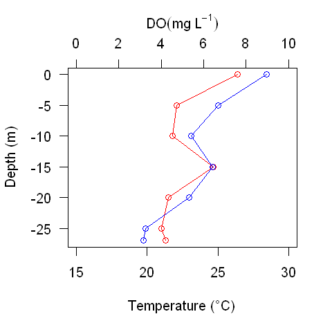

```r
depth<-c(0,-5,-10,-15,-20,-25,-27)
do<-c(8.97,6.67,5.41,6.41,5.31,3.25,3.15)
temp<-c(26.4,22.1,21.8,24.7,21.5,21.0,21.3)

plot(temp,depth, type="o",xlim=c(15,30),col=2, xlab="Temperature (°C)",ylab= "Depth (m)",las=1)
# the argument “las” specify the orientation of the text in the axes.

par(new=T)# The argument "new=T" specify that the next command shouldn't clean the plot

#window before plotting a new graph. In other words, it allows us to plot
# over the former graph.
plot(do,depth, type="o", xlim=c(0,10),col=4, axes=F, ann=F)#the argument “axes” specify if the axes should be plotted or not;
#The argument “ann” specify if axes titles should be plotted or not.
axis(3)
mtext(expression(DO(mg~L^-1)),side=3, line=2)# the “side” argument specify the position and the “line” argument specify the line
#where the text will show up.
```

Return to the Summary

### Multiple panels in a single plot area

To divide a plot in multiple panels, we can use the function “par” and its argument “mfrow”. See below.

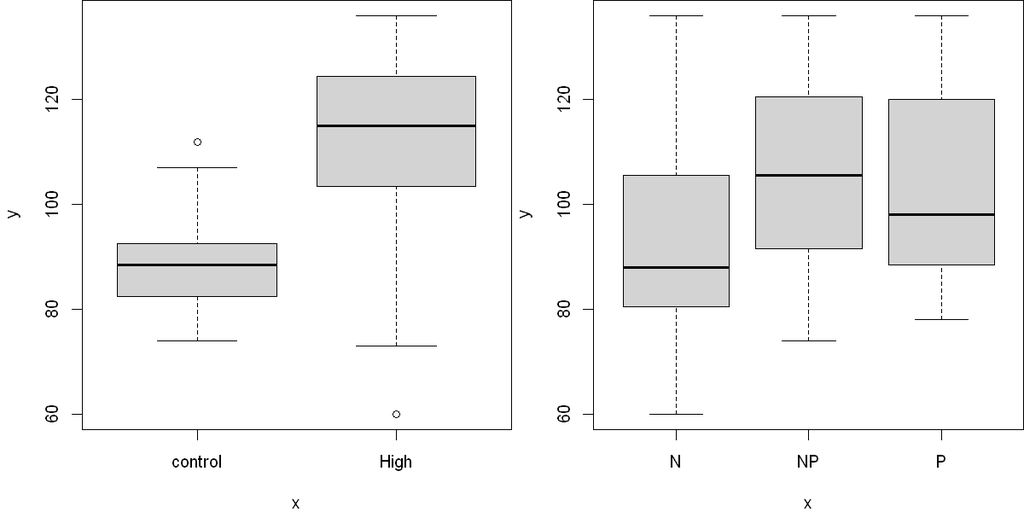

```r
ciano<-read.table("ciano.txt", header=T)

par(mfrow=c(1,2), mai=c(0.8,0.8,0,0))
#first element of “mfrow” indicate the number of rows, while the second one indicate the
#number of columns
plot(factor(ciano$temp), ciano$tox)
plot(factor(ciano$nutri), ciano$tox)
```

For ggplot, this can be done with the function plo_grid from the package cowplot

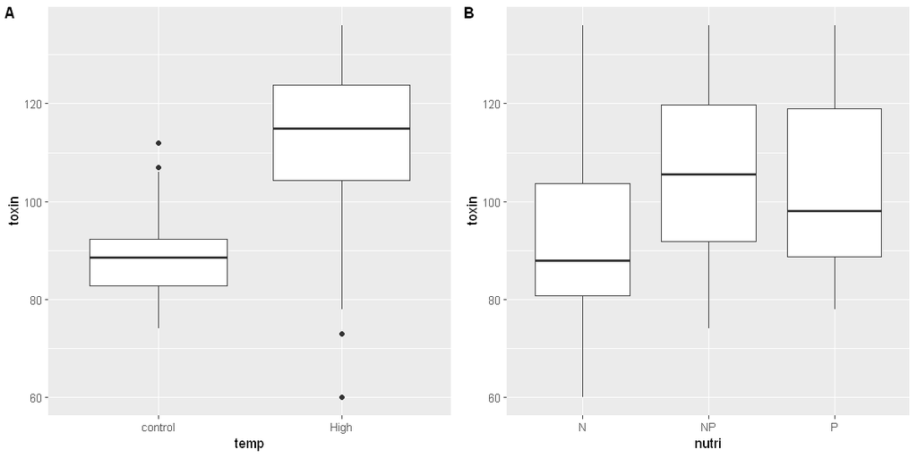

```r
require (ggplot2)
require (cowplot)

P1 <- ggplot (ciano, aes (x=temp, y=toxin)) + geom_boxplot ()
P2 <- ggplot (ciano, aes (x=nutri, y=toxin)) + geom_boxplot ()

plot_grid (P1,P2, ncol = 2, nrow= 1,
           labels = c('A', 'B'), label_size = 12)
```

To export the figure with quality, use the function “tiff” and “dev.off”. For instance:

```r
tiff(file="one_row_two_columns_example.tiff",width=3000,height=1500,units = "px",
     compression="lzw",res=300)
plot_grid (P1,P2, ncol = 2, nrow= 1,
           labels = c('A', 'B'), label_size = 12)
dev.off()
```

**png:** 2

Return to the Summary

## 4. Statistics

### Linear regression

Linear model containing a continuous dependent variable (response) and one continuous independent variable (explanatory). Main assumptions:

1. residuals are normally distributed
2. homogeneity of variance
3. Independence of sampling units

To explore linear regression, we are going to use the dataset "earth worm".

```r
earth_worm <- read.csv ("earth_worm.csv", header=T,sep=";")
```

The function to run linear regressions is “lm”. Here, we will explore how the soil pH affects the density of earth worms.

```r
regression <- lm (density ~ pH.soil, data=earth_worm)
```

To verify visually if the assumptions of the model were not violated (specially the i and ii), we can use the function “plot”.

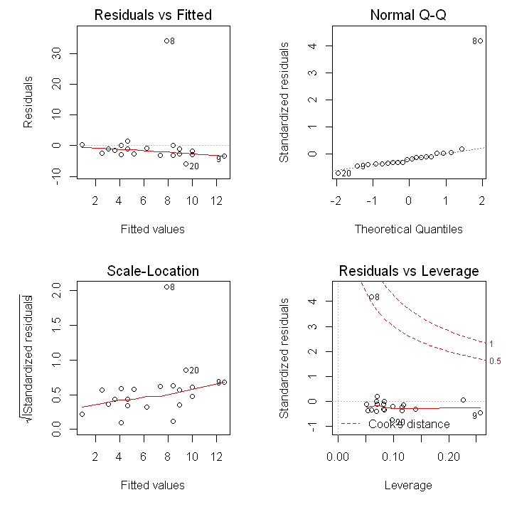

```r
par(mfrow=c(2,2),mai=c(0.9,0.9,0.3,0.3))
plot (regression)
```

There is a clear outlier in the dataset (#8)! In a serius study, the outlier should be investigated in more details. For the sake of time, here we are going to remove it from the analysis.

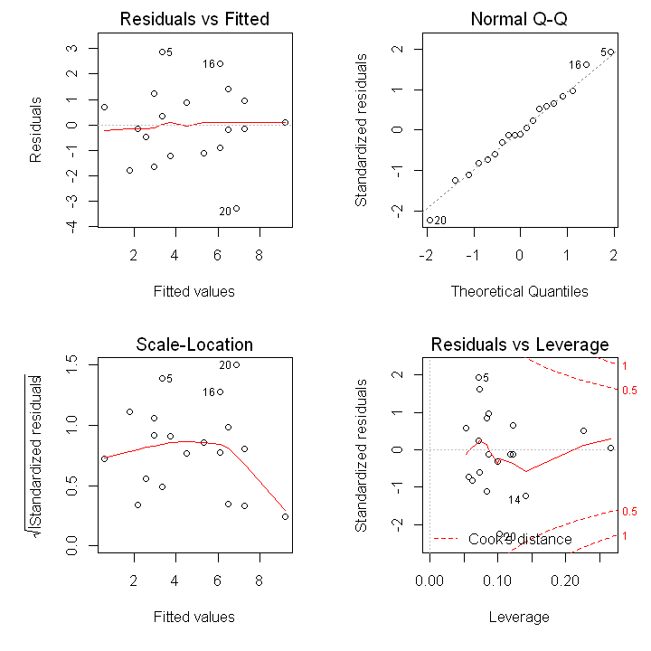

```r
earth_worm <- earth_worm [-8,] #remove outlier
regression <- lm (density ~ pH.soil, data=earth_worm) #run analysis again

par(mfrow=c(2,2),mai=c(0.9,0.9,0.3,0.3))
plot (regression) # check assumptions
```

Much better now! Assuming that all the assumptions were not violated, we can now explore the results using the function “summary”.

```r
summary (regression)
```

```
Call:
lm(formula = density ~ pH.soil, data = earth_worm)

Residuals:
    Min      1Q  Median      3Q     Max
-3.2709 -0.9950 -0.1628  0.9090  2.8567

Coefficients:
            Estimate Std. Error t value Pr(>|t|)
(Intercept) -13.1187     2.8184  -4.655 0.000227 ***
pH.soil       3.9195     0.6156   6.367 7.02e-06 ***
---
Signif. codes:  0 '***' 0.001 '**' 0.01 '*' 0.05 '.' 0.1 ' ' 1

Residual standard error: 1.539 on 17 degrees of freedom
Multiple R-squared:  0.7045,	Adjusted R-squared:  0.6871
F-statistic: 40.54 on 1 and 17 DF,  p-value: 7.024e-06
```

In this summary, we can verify the estimative and variance of the parameters (intercept and slope) and their respective p values according to a T statistic. The coefficient of determination (R²) and its adjusted version, F-statistic and p-value of the whole model can be found in the bottom of the summary. Now, let’s create a scatterplot and insert the trend line based on the model.

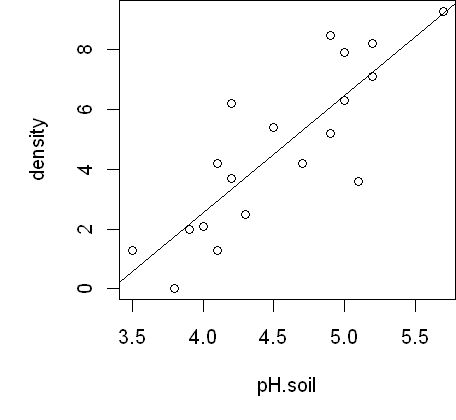

```r
par (mfrow=c(1,1),mai=c(1,1,0,0))
plot (density~pH.soil, data=earth_worm)
abline (regression)
```

Return to the Summary

### Multiple regression

Multiple regressions are essentially linear regressions with more than 1 explanatory variable (independent variables). Main assumptions:

1. residuals are normally distributed
2. homogeneity of variance
3. Independence of sampling units
4. No or little multicollinearity To explore this type of analysis, we are going to test the effect of the soil PH and the concentration of water in the soil on the density of earth worms. Thus, instead of conducting two linear regressions, we can test the effect of these two variables in a single analysis. To conduct a multiple regression, follow the code below.

```r
earth_worm <- read.csv ("earth_worm.csv", header=T,sep=";")
earth_worm <- earth_worm [-8,] # remove outlier

mult_regress <- lm (density ~ pH.soil+soaked, data=earth_worm)
#the plus sign indicates the function that we have one more explanatory variable
```

Before checking the results of the analysis, we should take a look on some diagnostic plots to see if the assumptions of the model were not violated.

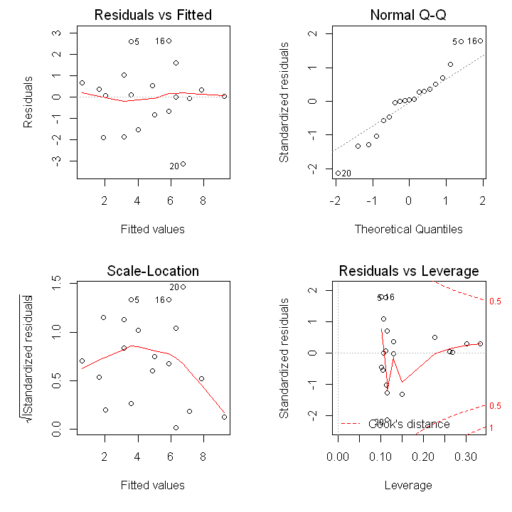

```r
par(mfrow=c(2,2),mai=c(0.9,0.9,0.3,0.3))
plot (mult_regress) # for normality, homogeneity of variance, and outliers
```

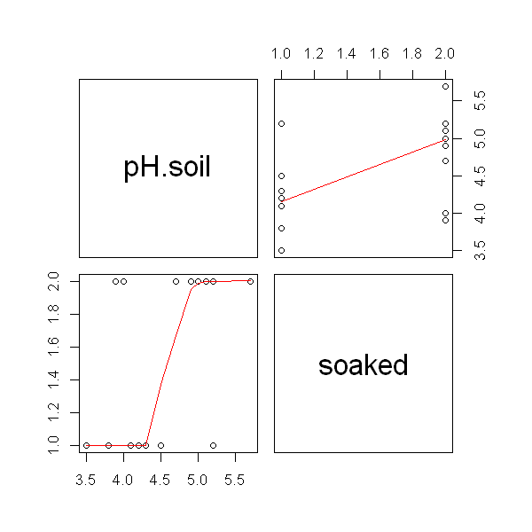

```r
par(mfrow=c(2,2),mai=c(0.9,0.9,0.3,0.3))
pairs(earth_worm[,5:6], panel=panel.smooth) # multicollinearity
```

```r
require (fmsb)
VIF(mult_regress)# if VIF is more than 10, multicolinearity is strongly suggested
```

3.52641666602006

Now, let’s check the results

```r
summary (mult_regress)
```

```
Call:
lm(formula = density ~ pH.soil + soaked, data = earth_worm)

Residuals:
     Min       1Q   Median       3Q      Max
-3.12576 -0.74988  0.05245  0.60339  2.62482

Coefficients:
            Estimate Std. Error t value Pr(>|t|)
(Intercept) -14.2651     3.1714  -4.498 0.000365 ***
pH.soil       4.2529     0.7430   5.724 3.14e-05 ***
soakedyes    -0.6991     0.8532  -0.819 0.424633
---
Signif. codes:  0 '***' 0.001 '**' 0.01 '*' 0.05 '.' 0.1 ' ' 1

Residual standard error: 1.554 on 16 degrees of freedom
Multiple R-squared:  0.7164,	Adjusted R-squared:  0.681
F-statistic: 20.21 on 2 and 16 DF,  p-value: 4.181e-05
```

To conclude, let’s make predictions using the model that we created.

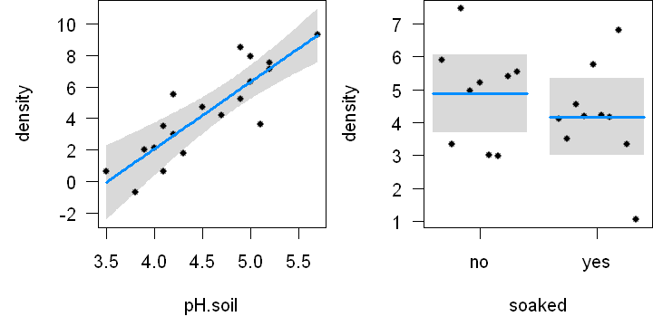

```r
require (visreg)

par(mfrow=c(1,2),mai=c(0.9,0.9,0,0))
turn.visreg<-visreg(mult_regress,
                    points=list(cex=0.9, pch=21, bg="black"))
```

Return to the Summary

### T-test and paired T-test

T-test is used to determine if there is a significant difference between the mean of two groups. Thus, to run this analysis, you need a continuous response variable and a categorical explanatory variable with two levels. Main assumptions:

1. residuals are normally distributed
2. homogeneity of variance
3. Independence of sampling units

To explore this analysis, please load the ciano_red database.

```r
ciano_red <- read.table("ciano_red.txt", h=T)
summary(ciano_red)
```

```
     toxin        temp        block
 Min.   :1   control:10   A      :2
 1st Qu.:3   high   :10   B      :2
 Median :4                C      :2
 Mean   :4                D      :2
 3rd Qu.:5                E      :2
 Max.   :7                F      :2
                          (Other):8
```

This dataset is the result of an experiment that investigated the level of toxin produced by cyanobacteria in two different temperatures (low and high). To conduct the analysis, we can use function "t.test".

```r
t.test(ciano_red$toxin ~ ciano_red$temp)
```

```
	Welch Two Sample t-test

data:  ciano_red$toxin by ciano_red$temp
t = -3.873, df = 18, p-value = 0.001115
alternative hypothesis: true difference in means is not equal to 0
95 percent confidence interval:
 -3.0849115 -0.9150885
sample estimates:
mean in group control    mean in group high
                    3                     5
```

Now, let’s compare the results with the function “lm”.

```r
summary(lm(toxin~temp, data = ciano_red))
```

```
Call:
lm(formula = toxin ~ temp, data = ciano_red)

Residuals:
   Min     1Q Median     3Q    Max
    -2     -1      0      1      2

Coefficients:
            Estimate Std. Error t value Pr(>|t|)
(Intercept)   3.0000     0.3651   8.216 1.67e-07 ***
temphigh      2.0000     0.5164   3.873  0.00111 **
---
Signif. codes:  0 '***' 0.001 '**' 0.01 '*' 0.05 '.' 0.1 ' ' 1

Residual standard error: 1.155 on 18 degrees of freedom
Multiple R-squared:  0.4545,	Adjusted R-squared:  0.4242
F-statistic:    15 on 1 and 18 DF,  p-value: 0.001115
```

This means that the results of the t.test function are equilavent to results of the lm function. Thus, the diagnostics can be conducted similarly with what we did in the linear regression section.

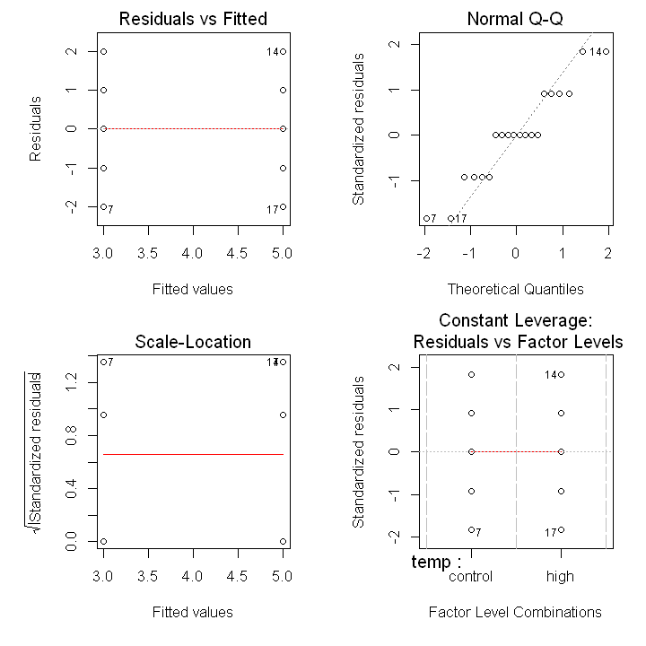

```r
par(mfrow=c(2,2),mai=c(0.9,0.9,0.3,0.3))
plot(lm(toxin~temp,
        data = ciano_red))
```

Now, let's make the predictions of the model.

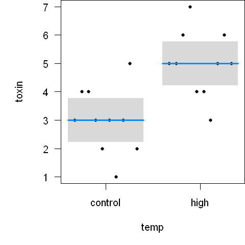

```r
require (visreg)

t_test <- lm(toxin~temp,data=ciano_red)

par (mai=c(1,1,0,0))
T_vis<-visreg(t_test, gg=F,
              points=list(cex=0.8, pch=21, bg="black"))
```

To finish this section, we will run a paired t-test. The logic of this analysis is the same of the t-test. The only different is that in the paired t-test each subject or entity (sampling unit) was measured twice, one for each treatment. To run a paired T-test, we just need to add the argument paired=T in the function t.test. Just be careful because this function creates the blocks (pairs) automatically based on the order of the sampling units in the dataframe.

```r
t.test(toxin~temp,
       data= ciano_red, paired=T)
```

```
	Paired t-test

data:  toxin by temp
t = -6.7082, df = 9, p-value = 8.771e-05
alternative hypothesis: true difference in means is not equal to 0
95 percent confidence interval:
 -2.674445 -1.325555
sample estimates:
mean of the differences
                     -2
```

Again, we can create an equivalent test using the function lm (linear regression). In order to do that, we just need to add the factor “block” to the analysis.

```r
summary( lm (toxin~temp+block,
             data=ciano_red))
```

```
Call:
lm(formula = toxin ~ temp + block, data = ciano_red)

Residuals:
   Min     1Q Median     3Q    Max
-1.000 -0.125  0.000  0.125  1.000

Coefficients:
              Estimate Std. Error t value Pr(>|t|)
(Intercept)  3.000e+00  4.944e-01   6.068 0.000186 ***
temphigh     2.000e+00  2.981e-01   6.708 8.77e-05 ***
blockB       5.000e-01  6.667e-01   0.750 0.472404
blockC       1.000e+00  6.667e-01   1.500 0.167851
blockD       1.000e+00  6.667e-01   1.500 0.167851
blockE      -1.000e+00  6.667e-01  -1.500 0.167851
blockF      -5.000e-01  6.667e-01  -0.750 0.472404
blockG      -2.000e+00  6.667e-01  -3.000 0.014956 *
blockH      -1.632e-15  6.667e-01   0.000 1.000000
blockI       1.500e+00  6.667e-01   2.250 0.051003 .
blockJ      -5.000e-01  6.667e-01  -0.750 0.472404
---
Signif. codes:  0 '***' 0.001 '**' 0.01 '*' 0.05 '.' 0.1 ' ' 1

Residual standard error: 0.6667 on 9 degrees of freedom
Multiple R-squared:  0.9091,	Adjusted R-squared:  0.8081
F-statistic:     9 on 10 and 9 DF,  p-value: 0.001437
```

Return to the Summary

### Analysis of Variance (ANOVA)

Analysis of Variance (ANOVA) is an analysis composed of one continuous response variable and categorical explanatory variables. People usually make the number of categorical variables explicit in the name of the analysis, for instance: One-way ANOVA (1 categorical variable), Two-way ANOVA (2 categorical variables), and so on. Main assumptions:

1. Residuals are normally distributed
2. Homogeneity of variance
3. Independence of sampling units
4. No or little multicollinearity

We will use an One-way ANOVA to explore how the density of earth worm vary among soils with different levels of water concentration (variable: soaked). The function that we will use is called "aov".

```r
earth_worm <- read.csv ("earth_worm.csv", header=T, sep=";")
earth_worm <- earth_worm [-8,] #remove outlier in line 8. See the linear regression section for
# more details or just try to run the analysis without removing line 8.
anova_worms <- aov (density~soaked, data=earth_worm)
```

To access diagnostic plots, you can again use the function “plot”.

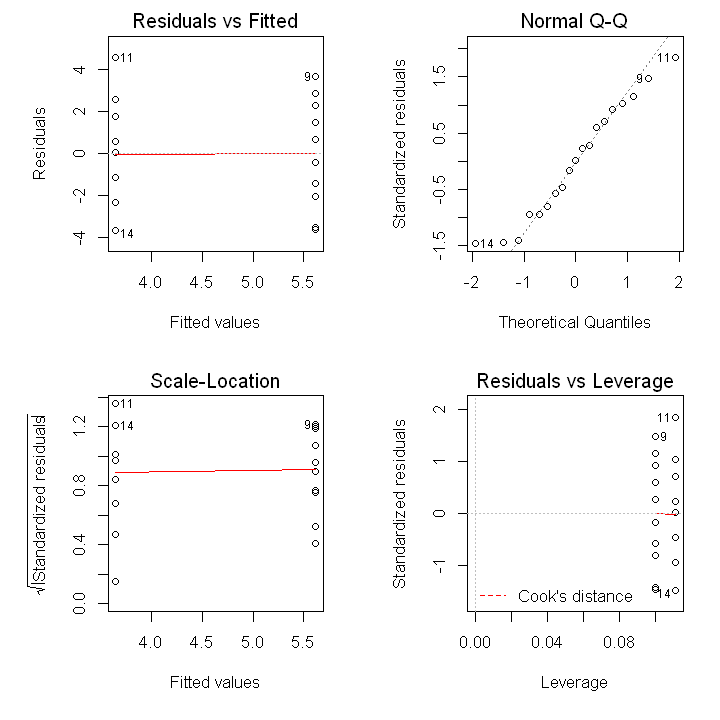

```r
par(mfrow=c(2,2),mai=c(0.9,0.9,0.3,0.3))
plot (anova_worms)
```

Now, let’s access the results of the analysis

```r
summary(anova_worms)
```

```
            Df Sum Sq Mean Sq F value Pr(>F)
soaked       1  18.49  18.487    2.67  0.121
Residuals   17 117.72   6.925
```

When the results are significant, it is usually expected that post-hoc tests are conducted to investigate more deeply into the diferences between categorical levels. Here, the results were non-significant. As a practice, let's run a posthoc test (Tukey HSD).

```r
TukeyHSD (anova_worms, conf.level=0.95)
```

```
  Tukey multiple comparisons of means
    95% family-wise confidence level

Fit: aov(formula = density ~ soaked, data = earth_worm)

$soaked
           diff        lwr      upr     p adj
yes-no 1.975556 -0.5753678 4.526479 0.1206526
```

Compare the results with a linear regression (the explanatory variable is automatically transformed into a dummy variable)

```r
lm_worms <- lm (density~soaked, data=earth_worm)
summary.aov (lm_worms)
```

```
            Df Sum Sq Mean Sq F value Pr(>F)
soaked       1  18.49  18.487    2.67  0.121
Residuals   17 117.72   6.925
```

To access the predictions of the model, we can use the function “predict”, the function “emmeans” of the package “emmeans”, or the function “visreg” of the package “visreg”. Here, we are going to use the function “emmeans”.

```r
require ("emmeans")
soaked_effect<-emmeans(anova_worms,"soaked")
(soaked_effect <-as.data.frame(soaked_effect)) # This par of extra parenthesis tells R to print
# the object (here, a data frame) that was created.
```

A data.frame: 2 × 6

|  | soaked <fct> | emmean <dbl> | SE <dbl> | df <dbl> | lower.CL <dbl> | upper.CL <dbl> |
| --- | --- | --- | --- | --- | --- | --- |
| 1 | no | 3.644444 | 0.8771546 | 17 | 1.793810 | 5.495079 |
| 2 | yes | 5.620000 | 0.8321419 | 17 | 3.864334 | 7.375666 |

No, we just need to create a plot with these predictions.

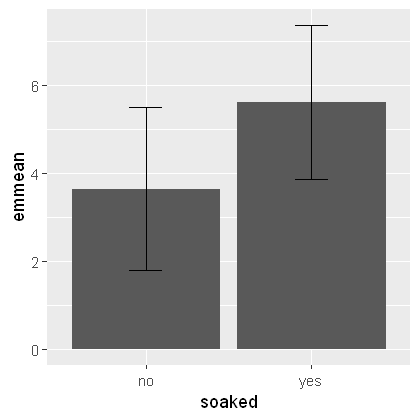

```r
require (ggplot2)

ggplot(soaked_effect, aes(x=soaked,y=emmean))+
  geom_bar (stat="identity", position="dodge")+
  geom_errorbar(aes(ymin=lower.CL, ymax=upper.CL),width=0.2)

#ggplot call the data and set the variables that will be used
#geom_bar creates the bars and geom_errorbar the errors of the bars.
```

Return to the Summary

### Generalized Linear Models (GLM)

GLMs are a flexible generalization of linear (multiple) regressions that allow the user to use response variables with different probability distributions (i.e., not just restricted to normal distribution). GLMs are composed of three main components:

**Systematic component:** The explanatory components (independent variables).  
**Random component:** the probability distribution of the response variable (binomial, gaussian, Gamma, inverse gaussian, poisson, quasi, quasibinomial, quasipoisson).  
**Link function:** link between random and systematic components. There is a default link function for each probability distribution, but this can be changed by the user (you have to know what you are doing). See the default options below:

| Probability distribution | Link function |
| --- | --- |
| Binomial | Logit |
| Gaussian | Identity |
| Gamma | Inverse |
| Inverse gaussian | 1/mu^2 |
| Poisson | Log |
| Quasi | Identity |
| Quasibinomial | Logit |
| Quasipoisson | Log |

Main assumptions:

1. Independence of sampling units
2. The residuals don’t need to be normal distributed, but should follow the distribution of the exponential family specified in the model (bionomial, poisson, etc).
3. Homogeneity of variance (some authors may disagree about this one)

Here, we will run three glm models with response variables with different probability distributions: poisson (count data – discrete numbers/integers), binomial (presence-absence, proportion data) and gaussian (continuous data). Let’s start with the normal distribution (gaussian). Load the “earth_worm” dataset.

```r
earth_worm <- read.csv ("earth_worm.csv", header=T,sep=";")
earth_worm <- earth_worm [-8,] #remove outlier in line 8. See the linear regression section for
# more details or just try to run the analysis without removing line 8.
summary(earth_worm)
```

```
 site      density           area           slope           pH.soil
 A: 9   Min.   :0.000   Min.   :0.800   Min.   : 0.000   Min.   :3.500
 B:10   1st Qu.:2.300   1st Qu.:2.300   1st Qu.: 1.000   1st Qu.:4.100
        Median :4.200   Median :3.100   Median : 2.000   Median :4.500
        Mean   :4.684   Mean   :3.037   Mean   : 3.684   Mean   :4.542
        3rd Qu.:6.700   3rd Qu.:3.750   3rd Qu.: 5.500   3rd Qu.:5.000
        Max.   :9.300   Max.   :5.100   Max.   :11.000   Max.   :5.700
 soaked       vegetacao
 no : 9   Arable   :2
 yes:10   Grassland:9
          Meadow   :3
          Orchard  :1
          Scrub    :4
```

Now, we will model the density of worms by the slope of the terrain.

```r
glm_gaus <- glm (density~slope,
                 family=gaussian(link = "identity"),
                 data=earth_worm)
```

You can also access some diagnostic plots using the function “plot” (see below). However, there are more efficient ways to assess the assumptions of glm models. For example, Dr. Paula provide R code to conduct envelope analysis and other diagnostic techniques for all family distributions that we are going to see here. To assess the codes, visit: https://www.ime.usp.br/~giapaula/textoregressao.htm

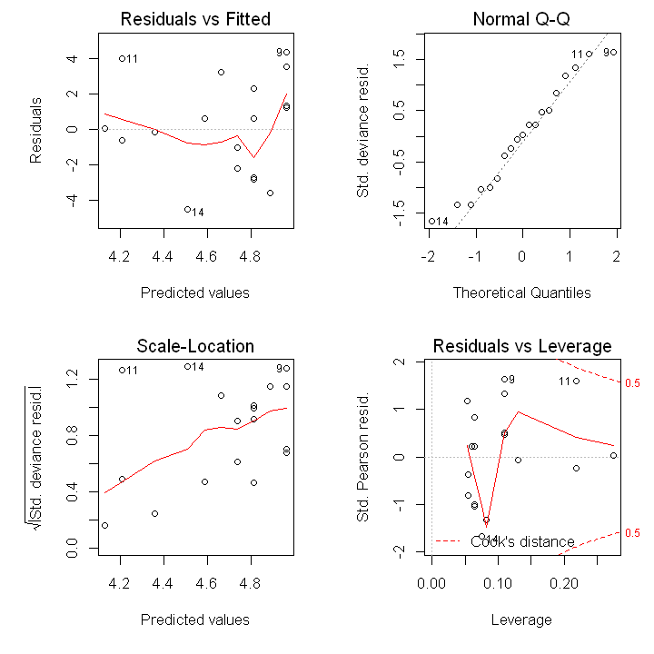

```r
par(mfrow=c(2,2),mai=c(0.9,0.9,0.3,0.3))
plot (glm_gaus)
```

The function summary is (again) used to present the results that we need.

```r
summary (glm_gaus)
```

```
Call:
glm(formula = density ~ slope, family = gaussian(link = "identity"),
    data = earth_worm)

Deviance Residuals:
    Min       1Q   Median       3Q      Max
-4.5097  -2.4735   0.0671   1.8135   4.3381

Coefficients:
            Estimate Std. Error t value Pr(>|t|)
(Intercept)  4.96186    0.93052   5.332  5.5e-05 ***
slope       -0.07536    0.18176  -0.415    0.684
---
Signif. codes:  0 '***' 0.001 '**' 0.01 '*' 0.05 '.' 0.1 ' ' 1

(Dispersion parameter for gaussian family taken to be 7.93186)

    Null deviance: 136.21  on 18  degrees of freedom
Residual deviance: 134.84  on 17  degrees of freedom
AIC: 97.153

Number of Fisher Scoring iterations: 2
```

The summary provides us the estimative of the parameters (intercept and slope) and also the t statistic and the p values associated. The AIC of the model is also provided. You can calculate the r² with the equation below:

```r
1 - (glm_gaus$deviance/ glm_gaus$null.deviance)
```

0.0100117264104984

Finally, let’s plot the data and add a trend line based on the predictions of our model.

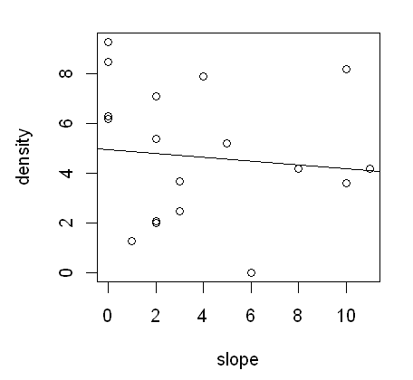

```r
par(mfrow=c(1,1),mai=c(0.9,0.9,0.3,0.3))
plot (density~slope, data=earth_worm)
abline(glm_gaus)
```

Now, we are going to run a glm to model count data. Load the dataset "area".

```r
area <- read.table ("area.txt", header=T)
summary(area)
```

```
      area            riq
 Min.   : 13.0   Min.   :40.00
 1st Qu.: 49.0   1st Qu.:49.00
 Median :130.0   Median :53.00
 Mean   :127.7   Mean   :54.33
 3rd Qu.:201.0   3rd Qu.:61.50
 Max.   :250.0   Max.   :70.00
```

This dataset contains two columns: richness and area. Richness is simply the count of species, so we should use family=poisson rather than family=gaussian to model the data. Let’s do it!

```r
glm_pois<-glm (riq ~ area,
               family=poisson,data=area) #since we are going to use the default option for
#the link function, we can just use family=poisson.
```

Diagnostic plots using the “function” plot is also available for family=poisson. Poisson distribution assumes that the variance is equal to the mean, so we also should check if our model does not have overdispersion (this is a common problem with this kind of model). To test that, we can use the function “dispersiontest” available in the “AER package”.

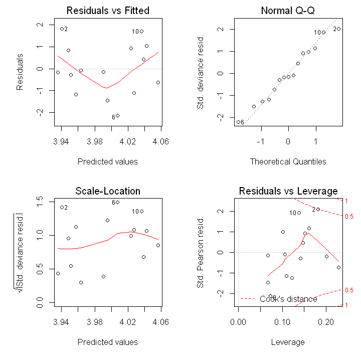

```r
par(mfrow=c(2,2),mai=c(0.9,0.9,0.3,0.3))
plot(glm_pois)
```

```r
require (AER)
dispersiontest (glm_pois) # test for overdispersion
```

```
	Overdispersion test

data:  glm_pois
z = 0.71635, p-value = 0.2369
alternative hypothesis: true dispersion is greater than 1
sample estimates:
dispersion
  1.251859
```

A good way to check for overdispersion in count models is by looking at hanging rootogram, which compare the empirical frequencies (observed data) with fitted frequencies. Gray bars over the 0 line indicate overfitting, and bars under the 0 line suggest underfitting. At the zero line, the model fits the data perfectly. Consider using Negative Binomial generalized linear model, hurdle and zero-inflated regressions rather than Poisson GLM when overdispersion/underdispersion is high.

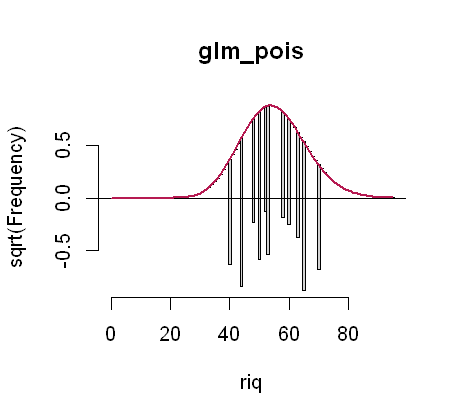

```r
#install.packages("countreg", repos="http://R-Forge.R-project.org")
options(repr.plot.width=3.8, repr.plot.height=3.5, repr.plot.res = 120,
       repr.plot.quality=600)
require (countreg)
rootogram(glm_pois, max = 95) # Vizualise under/over dispersion
```

Let’s access the results using "summary" and then plot the predictions of the model

```r
summary (glm_pois)
```

```
Call:
glm(formula = riq ~ area, family = poisson, data = area)

Deviance Residuals:
    Min       1Q   Median       3Q      Max
-2.1294  -0.8729  -0.1467   0.8835   1.8151

Coefficients:
             Estimate Std. Error z value Pr(>|z|)
(Intercept) 3.9292813  0.0674604  58.246   <2e-16 ***
area        0.0005091  0.0004402   1.157    0.247
---
Signif. codes:  0 '***' 0.001 '**' 0.01 '*' 0.05 '.' 0.1 ' ' 1

(Dispersion parameter for poisson family taken to be 1)

    Null deviance: 20.222  on 14  degrees of freedom
Residual deviance: 18.883  on 13  degrees of freedom
AIC: 110.24

Number of Fisher Scoring iterations: 4
```

```r
1 - (glm_pois$deviance/ glm_pois$null.deviance)#r2
```

0.0662204681864803

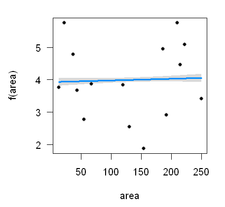

```r
require (visreg)

par(mfrow=c(1,1),mai=c(0.9,0.9,0.3,0.3))
glm_poiss.visreg<-visreg(glm_pois,
              points=list(cex=0.9, pch=21, bg="black"))
```

Finally, we will conduct a glm with a binary response variable. The data that we are going to use is called "cannibalism" and contains data of cannibalism events (0 and 1) in a given species along a latitudinal gradient. Load the dataset to R.

```r
cannibalism <- read.table ("cannibalism.txt", header=T)
summary(cannibalism)
```

```
 Cannibalism    Latitude
 No :18      Min.   :10
 Yes:11      1st Qu.:17
             Median :24
             Mean   :24
             3rd Qu.:31
             Max.   :38
```

To avoid problems in the analysis, we are going to replace “Yes” with “1” and No with “0”

```r
cannibalism$Cannibalism<- ifelse (cannibalism$Cannibalism=="Yes",1,0)
summary(cannibalism)
```

```
  Cannibalism        Latitude
 Min.   :0.0000   Min.   :10
 1st Qu.:0.0000   1st Qu.:17
 Median :0.0000   Median :24
 Mean   :0.3793   Mean   :24
 3rd Qu.:1.0000   3rd Qu.:31
 Max.   :1.0000   Max.   :38
```

Cannibalism is being considered a continuous variable, let's fix this.

```r
cannibalism$Cannibalism <- factor (cannibalism$Cannibalism)
```

Now we can run the model. Since the response variable is composed of presence-absence, we have to use the family=binomial.

```r
glm_bino<-glm (Cannibalism~Latitude,
               family=binomial,data=cannibalism)
```

Check assumptions:

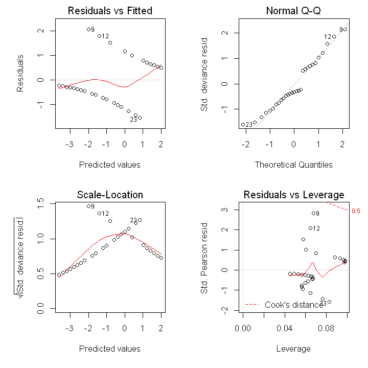

```r
par(mfrow=c(2,2),mai=c(0.9,0.9,0.3,0.3))
plot (glm_bino)
```

Now, we just have to check the results and plot the predictions of the model

```r
summary (glm_bino)
```

```
Call:
glm(formula = Cannibalism ~ Latitude, family = binomial, data = cannibalism)

Deviance Residuals:
    Min       1Q   Median       3Q      Max
-1.5377  -0.7274  -0.3111   0.6582   2.0620

Coefficients:
            Estimate Std. Error z value Pr(>|z|)
(Intercept) -5.61830    2.03302  -2.764  0.00572 **
Latitude     0.20108    0.07414   2.712  0.00669 **
---
Signif. codes:  0 '***' 0.001 '**' 0.01 '*' 0.05 '.' 0.1 ' ' 1

(Dispersion parameter for binomial family taken to be 1)

    Null deviance: 38.496  on 28  degrees of freedom
Residual deviance: 26.650  on 27  degrees of freedom
AIC: 30.65

Number of Fisher Scoring iterations: 5
```

```r
1 - (glm_bino$deviance/ glm_bino$null.deviance)#r2
```

0.307734637471965

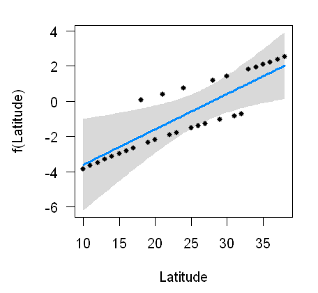

```r
par(mfrow=c(1,1),mai=c(0.9,0.9,0.3,0.3))
glm_bino_visreg<-visreg(glm_bino,
                        points=list(cex=0.9, pch=21, bg="black"))
```

Return to the Summary

### Generalized Least Squares (GLS)

A Generalized Least Square (GLS) is a method of parameter estimation which accounts for the structure in the error term. In this sense, it can be used to model heterosdasticity in the data and also the lack of independence caused by evolutionary history (phylogenetic component). In this section, we are going to see how we can deal with these two peculiarities of ecological data. Please, load the “Squid” dataset in R. The goal here is to explore how testicle weight of squids vary with body size (dorsal mantle length - DML).

```r
squid <- read.table ("Squid.txt",header=T)
summary (squid)
```

```
    Specimen         YEAR          MONTH        DML         Testisweight
 Min.   :1001   Min.   :1990   Min.   :9   Min.   :125.0   Min.   : 0.008
 1st Qu.:1006   1st Qu.:1990   1st Qu.:9   1st Qu.:212.0   1st Qu.: 1.051
 Median :1026   Median :1990   Median :9   Median :273.0   Median : 3.986
 Mean   :1026   Mean   :1990   Mean   :9   Mean   :273.1   Mean   : 5.988
 3rd Qu.:1041   3rd Qu.:1991   3rd Qu.:9   3rd Qu.:324.0   3rd Qu.: 9.400
 Max.   :1073   Max.   :1991   Max.   :9   Max.   :439.0   Max.   :20.422
```

Let’s see the heterosdasticity of the data running a simple linear regression and plotting the residuals.

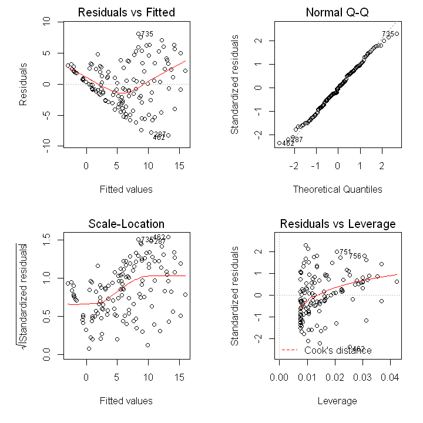

```r
linear_reg <- lm (Testisweight~DML, data=squid)
par(mfrow=c(2,2),mai=c(0.9,0.9,0.3,0.3))
plot(linear_reg)
```

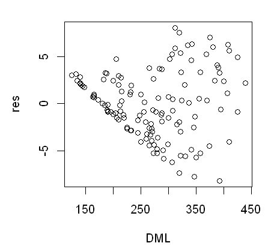

```r
res<-residuals(linear_reg,type="pearson")

par(mfrow=c(1,1),mai=c(0.9,0.9,0.3,0.3))
plot(res~DML,data=squid) #The variation increases as the DML increases
```

Now, we are going to conduct a gls with a variance structure that is proportional to DML (allows higher variance at higher values). First load the package nlme.

```r
require (nlme)
```

Second, we set the variance structure

```r
vf <- varPower(form =~ DML)# this is just a way to model the variance,
#there are several other methods too
```

Third, we run the model and check the residuals

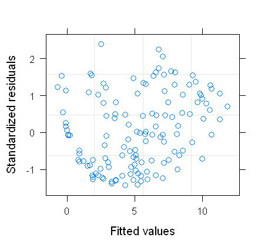

```r
gls_model <- gls(Testisweight ~ DML , weight= vf, data=squid)

plot(gls_model)
```

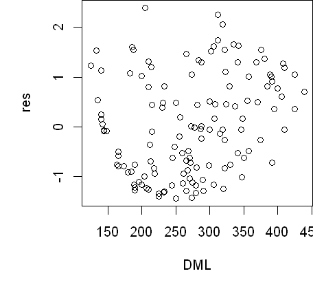

```r
res<-residuals (gls_model, type="pearson")
par (mai=c(1,1,0,0))
plot (res~DML,squid) #not perfect, but way better
```

Finally, we access the results using “summary” and plot the data and a trend line according to our model.

```r
summary (gls_model)
```

```
Generalized least squares fit by REML
  Model: Testisweight ~ DML
  Data: squid
       AIC      BIC    logLik
  679.1823 690.6831 -335.5911

Variance function:
 Structure: Power of variance covariate
 Formula: ~DML
 Parameter estimates:
   power
2.183381

Coefficients:
                Value Std.Error   t-value p-value
(Intercept) -5.679371 0.5412940 -10.49221       0
DML          0.039943 0.0028803  13.86764       0

 Correlation:
    (Intr)
DML -0.957

Standardized residuals:
        Min          Q1         Med          Q3         Max
-1.44088488 -0.81294878 -0.05826737  0.91389589  2.39465729

Residual standard error: 1.532355e-05
Degrees of freedom: 133 total; 131 residual
```

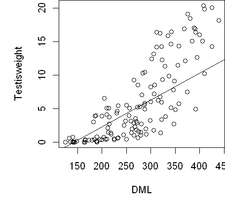

```r
par (mai=c(1,1,0,0))
plot (Testisweight ~ DML, data= squid)
abline (gls_model)
# probably a log transformation of both Testisweight and DML would improve the model a lot,
#this seems to be a exponentiation relationship rather than a linear one.
```

Our next example is about controlling the lack of independence in the data caused by the shared ancestry of some species and the widespread phenomenon of niche conservatism. This issue is very common in comparative studies. Load the package “caper” and the dataset “shorebird”.

```r
require (caper)
data (shorebird)
head (shorebird.data)
```

A data.frame: 6 × 6

|  | Species <chr> | M.Mass <dbl> | F.Mass <dbl> | Egg.Mass <dbl> | Cl.size <dbl> | Mat.syst <fct> |
| --- | --- | --- | --- | --- | --- | --- |
| Actophilornis_africanus | Actophilornis_africanus | 143.2 | 260.7 | 8.6 | 4.00 | PA |
| Aphriza_virgata | Aphriza_virgata | 186.3 | 216.3 | 22.4 | 4.00 | MO |
| Arenaria_interpres | Arenaria_interpres | 108.0 | 113.0 | 17.9 | 3.50 | MO |
| Arenaria_melanocephala | Arenaria_melanocephala | 113.6 | 124.2 | 17.3 | 4.00 | MO |
| Bartramia_longicauda | Bartramia_longicauda | 151.0 | 164.0 | 23.5 | 3.99 | MO |
| Calidris_alba | Calidris_alba | 52.8 | 55.4 | 11.2 | 3.90 | PA |

By loading the data, two objects are created in your workspace: a dataframe with 6 columns and 71 observations, and a "tree" file containing the phylogenetic similarity of all species in the shorebird dataset. We can visualize the tree using the function plot.

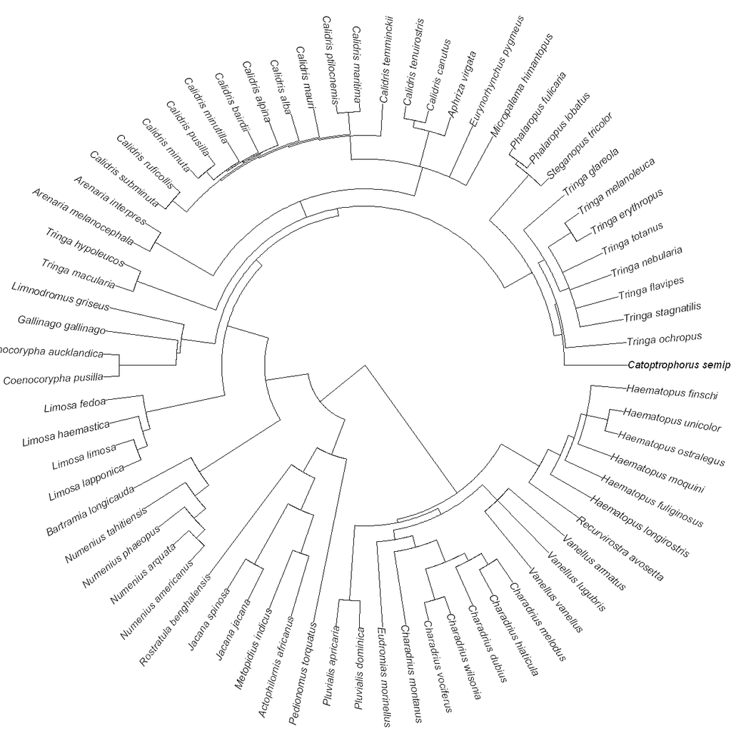

```r
par(mfrow=c(1,1),mai=c(0,0,0,0))
plot (shorebird.tree, type="fan", cex=0.6)
```

Just in case, let’s check if all species present in the dataset are in the phylogenetic tree.

```r
print(
setdiff(shorebird.data$Species,shorebird.tree$tip.label))
```

```
character(0)
```

Now that we are confident that these two files match perfectly, let’s conduct a phylogenetic generalized least squares model (PGLS) between egg mass (response variable) and the body mass (explanatory variable).

```r
shorebird <- comparative.data (shorebird.tree, shorebird.data, Species, vcv=TRUE)
#combine the phylogenetic tree and the dataframe with our variables; vcv= true
#calculates a variance-covariance matrix of the phylogeny.
```

```r
pgls.model <- pgls(log(Egg.Mass) ~ log(M.Mass), shorebird, lambda='ML')
#lambda is a measured of the strength of the phylogenetic signal and here is
#calculate using Maximum Likelihood. Values close to 1 means that the traits are
#correlated according to a Brownian motion model of evolution. Values close to 0
#indicate the data points are essentially independent.
```

We can check the results using the function “summary”, which is similar to what we already seen in other linear models.

```r
summary(pgls.model)
```

```
Call:
pgls(formula = log(Egg.Mass) ~ log(M.Mass), data = shorebird,
    lambda = "ML")

Residuals:
     Min       1Q   Median       3Q      Max
-0.07185 -0.02390 -0.00042  0.01901  0.06857

Branch length transformations:

kappa  [Fix]  : 1.000
lambda [ ML]  : 0.956
   lower bound : 0.000, p = < 2.22e-16
   upper bound : 1.000, p = 0.047331
   95.0% CI   : (0.867, 1.000)
delta  [Fix]  : 1.000

Coefficients:
             Estimate Std. Error t value Pr(>|t|)
(Intercept) -0.486129   0.205686 -2.3635  0.02093 *
log(M.Mass)  0.688645   0.032647 21.0937  < 2e-16 ***
---
Signif. codes:  0 '***' 0.001 '**' 0.01 '*' 0.05 '.' 0.1 ' ' 1

Residual standard error: 0.02905 on 69 degrees of freedom
Multiple R-squared: 0.8657,	Adjusted R-squared: 0.8638
F-statistic: 444.9 on 1 and 69 DF,  p-value: < 2.2e-16
```

Let’s plot the data and fit a trend line using our model.

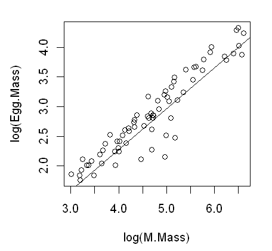

```r
par(mfrow=c(1,1),mai=c(0.9,0.9,0.3,0.3))
plot (log(Egg.Mass) ~ log(M.Mass), data=shorebird.data)
abline(pgls.model)
```

Return to the Summary

### Mixed model

Mixed models are used to analyze nested data (sometimes also called hierarchical data or multilevel data). For instance, many observations of the same subject are not independent. This hamper us to use regular linear models (such as ANOVA, linear regression, etc) due to the assumption of independence of sampling units (iii). In the past, many researches use to calculate means for each individual and then analyze the data with regular linear models. However, this approach reduces sample size and also hide intrinsic variation at the individual level. Mixed models were created to overcome this issue with its extra random term. In other words, the mixed model allows us to model individual variance (or other non-independent observations) by assuming different intercepts or even slopes for each individual. Main assumptions

1. The errors have constant variance (Homogeneity of variance)
2. The errors are independent
3. The errors are normally distributed

To explore mixed models in R, we are going to use the dataset RIKZ, which was download from the package AED. Take a look on the figure below to understand the data structure:

[figure not shown]

Source: Zuur et al. (2009) Mixed Effects Models and Extensions in Ecology with R This dataset is composed of richness measurements (macrofauna) taken on 9 beaches, and on each beach 5 sites were sampled. As you can imagine, all the sites sampled in each beach are not independent of each other, they are pseudo-replicates.

Let’s start loading the data to R.

```r
RIKZ<-read.table ("RIKZ.txt", header=T)
```

```r
summary(RIKZ) # Beach is being considered a continuous variable. We don't want that
```

```
     Sample      Richness         Exposure          NAP              Beach
 Min.   : 1   Min.   : 0.000   Min.   : 8.00   Min.   :-1.3360   Min.   :1
 1st Qu.:12   1st Qu.: 3.000   1st Qu.:10.00   1st Qu.:-0.3750   1st Qu.:3
 Median :23   Median : 4.000   Median :10.00   Median : 0.1670   Median :5
 Mean   :23   Mean   : 5.689   Mean   :10.22   Mean   : 0.3477   Mean   :5
 3rd Qu.:34   3rd Qu.: 8.000   3rd Qu.:11.00   3rd Qu.: 1.1170   3rd Qu.:7
 Max.   :45   Max.   :22.000   Max.   :11.00   Max.   : 2.2550   Max.   :9
```

```r
RIKZ$Beach<- factor(RIKZ$Beach) #fixed
```

NAP stands for NAP the height of a sampling station compared to mean tidal level. Exposure is an index composed of wave action, length of the surf zone, slope, grain size, and the depth of the anaerobic layer. Here, we are interested about how NAP and exposure affect the richness of the macrofauna. Richness is count data, so the best approach would be using a generalized linear mixed model (GLMM) with poisson distribution. We will do this in a minute, but, for the sake of simplicity, let’s use linear mixed model for now. To run a random intercept linear mixed model, we can use the function “lmer” of the package “lme4”.

```r
require (lme4)
require (lmerTest)
# random intercept linear mixed model
random_interc_model <- lmer (Richness~NAP+Exposure+(1|Beach),data=RIKZ)
```

To ensure that the assumptions are not being violated, we can use some diagnostic plots. See below.

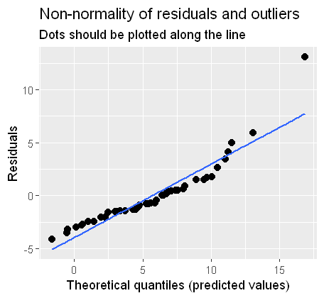

```r
require (sjPlot)
require (cowplot)
plot_model (random_interc_model,type="diag")[[1]]
```

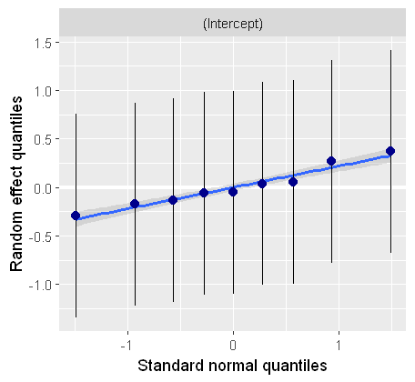

```r
plot_model (random_interc_model,type="diag")[[2]]
```

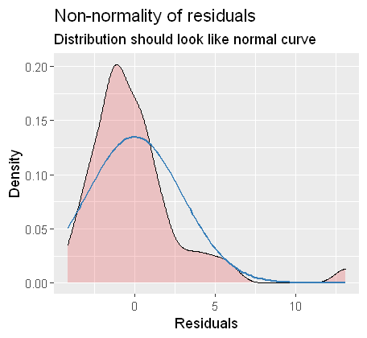

```r
plot_model (random_interc_model,type="diag")[[3]]
```

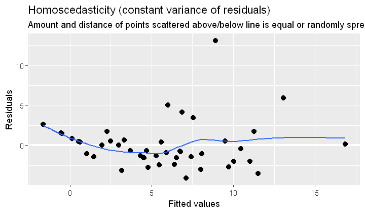

```r
plot_model (random_interc_model,type="diag")[[4]]
```

Now, we will check the results.

```r
summary(random_interc_model)
```

```
Linear mixed model fit by REML. t-tests use Satterthwaite's method [
lmerModLmerTest]
Formula: Richness ~ NAP + Exposure + (1 | Beach)
   Data: RIKZ

REML criterion at convergence: 225.5

Scaled residuals:
    Min      1Q  Median      3Q     Max
-1.3462 -0.5025 -0.2306  0.2150  4.2746

Random effects:
 Groups   Name        Variance Std.Dev.
 Beach    (Intercept) 0.3378   0.5812
 Residual             9.3735   3.0616
Number of obs: 45, groups:  Beach, 9

Fixed effects:
            Estimate Std. Error      df t value Pr(>|t|)
(Intercept)  37.2974     5.5547  6.7064   6.715 0.000330 ***
NAP          -2.6941     0.4700 41.5377  -5.732 9.98e-07 ***
Exposure     -3.0005     0.5417  6.7290  -5.539 0.000996 ***
---
Signif. codes:  0 '***' 0.001 '**' 0.01 '*' 0.05 '.' 0.1 ' ' 1

Correlation of Fixed Effects:
         (Intr) NAP
NAP       0.018
Exposure -0.996 -0.047
```

The summary provides us a lot of information. Focus on the Fixed effect section. You can see the estimation of the parameters, the standard error associated, t value, and P values.

Now let’s calculate the marginal (explanation of the main factors alone) and conditional R² (explanation of main factors + random variables) using the function r.squaredGLMM of the package MuMIn.

```r
require (MuMIn)
r.squaredGLMM(random_interc_model)
```

| R2m | R2c |
| --- | --- |
| 0.6172484 | 0.6305637 |

The next step is to verify the predictions of the model. An easy way to do it is using the function “plot_model” of the package “sjPlot”. For instance,

```
Package `effects` is not available, but needed for `ggeffect()`. Either install package `effects`, or use `ggpredict()`. Calling `ggpredict()` now.FALSE
```

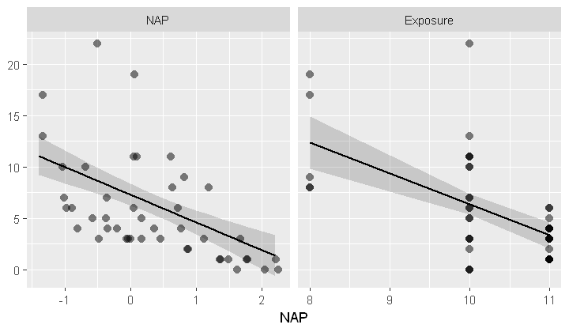

```r
plot_model(random_interc_model,type = "eff",show.data=TRUE,grid=TRUE)
```

To conclude, we will explore the random intercept values created by the model.

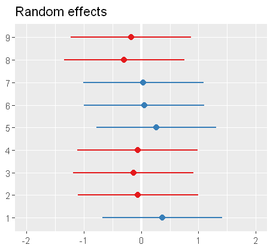

```r
plot_model (random_interc_model,type = "re")
```

```r
random_interc_slope_model <- lmer (Richness~ NAP+(NAP|Beach),
                             data=RIKZ)
```

```r
#Random intercept random slope generalized linear mixed model
glmm_inter_slope<-glmer (Richness~NAP+(NAP |Beach),family=poisson,data=RIKZ)
```

Return to the Summary

### Model selection and cross validation

So far, we learned how to conduct a bunch of models in R. However, little was said about how we can define which variables should be kept in the models and which should be dropped. That’s exactly what we are going to do now. We also going to explore the concept of out-of-sample evaluation using cross-validation. For this section, we are going to use the PhDPublications dataset.

```r
options(scipen = 999) # disabling scientific notation
PhDPublications <- read.table("PhDPublications.csv",header=TRUE)
summary(PhDPublications)
```

```
    articles         gender    married        kids           prestige
 Min.   : 0.000   female:421   no :309   Min.   :0.0000   Min.   :0.755
 1st Qu.: 0.000   male  :494   yes:606   1st Qu.:0.0000   1st Qu.:2.260
 Median : 1.000                          Median :0.0000   Median :3.150
 Mean   : 1.693                          Mean   :0.4951   Mean   :3.103
 3rd Qu.: 2.000                          3rd Qu.:1.0000   3rd Qu.:3.920
 Max.   :19.000                          Max.   :3.0000   Max.   :4.620
     mentor
 Min.   : 0.000
 1st Qu.: 3.000
 Median : 6.000
 Mean   : 8.767
 3rd Qu.:12.000
 Max.   :77.000
```

Now, we are going to create a global model with all the variables together.

```r
global_model<-lm (articles~gender+married+kids+prestige+mentor,
                  data=PhDPublications)
```

Let’s check the multicollinearity among the variables. High levels of multicollinearity may cause several problems during the model selection process.

```r
require (fmsb)
VIF(global_model) # If VIF is more than 10, multicolinearity is strongly suggested
```

1.1240531525903

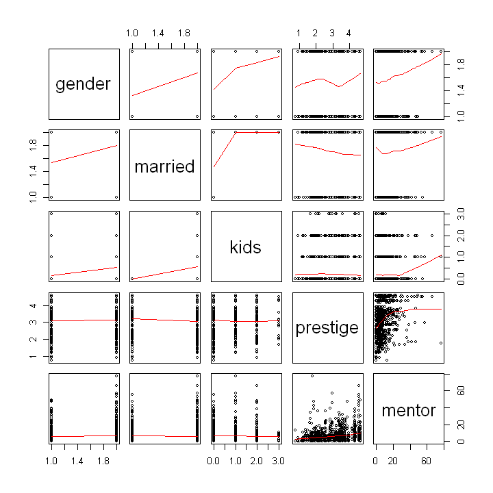

```r
pairs(PhDPublications[,2:ncol(PhDPublications)],
      panel=panel.smooth,cex=0.6)
```

The first way we can select variables is using a stepwise process. One variable will be dropped (backwards) or added (forward) at a time. Here, we are going to use the AIC criterion to compare different models. The function that we will use is called “stepAIC” from the package “MASS”. The first way we can select variables is using a stepwise process. One variable will be dropped (backwards) or added (forward) at a time. Here, we are going to use the AIC criterion to compare different models. The function that we will use is called “stepAIC” from the package “MASS”.

```r
require (MASS)
stepAIC (global_model,direction="forward")# forward
```

```
Start:  AIC=1103.53
articles ~ gender + married + kids + prestige + mentor
```

```
Call:
lm(formula = articles ~ gender + married + kids + prestige +
    mentor, data = PhDPublications)

Coefficients:
(Intercept)   gendermale   marriedyes         kids     prestige       mentor
    0.95336      0.38089      0.26320     -0.29144     -0.01137      0.06149
```

```r
stepAIC (global_model,direction="backward")# backwards
```

```
Start:  AIC=1103.53
articles ~ gender + married + kids + prestige + mentor

           Df Sum of Sq    RSS    AIC
- prestige  1     0.106 3016.6 1101.6
<none>                  3016.5 1103.5
- married   1    10.870 3027.4 1104.8
- gender    1    29.320 3045.8 1110.4
- kids      1    34.098 3050.6 1111.8
- mentor    1   287.632 3304.1 1184.9

Step:  AIC=1101.56
articles ~ gender + married + kids + mentor

          Df Sum of Sq    RSS    AIC
<none>                 3016.6 1101.6
- married  1    11.116 3027.7 1102.9
- gender   1    29.249 3045.9 1108.4
- kids     1    34.088 3050.7 1109.8
- mentor   1   305.202 3321.8 1187.8
```

```
Call:
lm(formula = articles ~ gender + married + kids + mentor, data = PhDPublications)

Coefficients:
(Intercept)   gendermale   marriedyes         kids       mentor
    0.91968      0.38030      0.26529     -0.29140      0.06119
```

We can also compare models with all possible combination of fixed variables using the “dredge” and “model.sel” functions of the package “MuMIn”. See the example below.

```r
require (MuMIn)
options(na.action = "na.fail")#avoid an weird error in R
mult_models <-dredge (global_model)
All_models <- model.sel(mult_models,rank="AIC")
head (All_models)
```

```
Fixed term is "(Intercept)"
New rank 'AIC' applied to logLik objects
```

|  | (Intercept) | gender | kids | married | mentor | prestige | df | logLik | AIC | delta | weight |
| --- | --- | --- | --- | --- | --- | --- | --- | --- | --- | --- | --- |
| 16 | 0.9196811 | + | -0.2913990 | + | 0.06118961 | NA | 6 | -1844.109 | 3700.218 | 0.000000 | 0.46608680 |
| 12 | 1.0464189 | + | -0.2214561 | NA | 0.06088456 | NA | 5 | -1845.792 | 3701.584 | 1.365411 | 0.23548954 |
| 32 | 0.9533633 | + | -0.2914422 | + | 0.06149458 | -0.01136511 | 7 | -1844.093 | 3702.186 | 1.967924 | 0.17423589 |
| 28 | 1.1057830 | + | -0.2225355 | NA | 0.06144284 | -0.02064269 | 6 | -1845.739 | 3703.478 | 3.259286 | 0.09135277 |
| 10 | 0.9927553 | + | NA | NA | 0.06068518 | NA | 4 | -1849.391 | 3706.782 | 6.563744 | 0.01750523 |
| 15 | 1.0450673 | NA | -0.2351045 | + | 0.06275954 | NA | 5 | -1848.524 | 3707.048 | 6.829150 | 0.01532977 |

Please, notice that this approach was criticized by Burnham and Anderson (2002) given that this automatic process may be creating models that don’t make biological sense. A better approach would be if we create some alternative models that make sense and then compared them. For example:

```r
model_ind <- lm (articles~gender+married+kids,
                  data=PhDPublications)
model_ment <- lm (articles~prestige+mentor,
                  data=PhDPublications)

model.sel (model_ind,model_ment, rank="AIC")
# Variables related with the mentor are stronger predictor your scientific success than
# variables related with the individual.
```

|  | (Intercept) | gender | kids | married | mentor | prestige | df | logLik | AIC | delta | weight |
| --- | --- | --- | --- | --- | --- | --- | --- | --- | --- | --- | --- |
| model_ment | 1.186283 | NA | NA | NA | 0.06247492 | -0.01325066 | 4 | -1852.636 | 3713.272 | 0.00000 | 0.9999999999999997779554 |
| model_ind | 1.415927 | + | -0.2726155 | + | NA | NA | 5 | -1888.202 | 3786.403 | 73.13129 | 0.0000000000000001317473 |

Finally, we can use a model averaging approach to estimate the importance of each variable based on multiple models.

```r
options(na.action = "na.fail")#avoid an weird error in R
mult_models <-dredge (global_model)
Mod_avg <- model.avg (mult_models, rank="AIC")
summary(Mod_avg)
```

```
Fixed term is "(Intercept)"
```

```
Call:
model.avg(object = get.models(object = mult_models, subset = NA),
    rank = "AIC")

Component model call:
lm(formula = articles ~ <32 unique rhs>, data = PhDPublications)

Component models:
       df   logLik     AIC delta weight
1234    6 -1844.11 3700.22  0.00   0.45
124     5 -1845.79 3701.58  1.37   0.23
12345   7 -1844.09 3702.19  1.97   0.17
1245    6 -1845.74 3703.48  3.26   0.09
14      4 -1849.39 3706.78  6.56   0.02
234     5 -1848.52 3707.05  6.83   0.01
134     5 -1849.25 3708.50  8.28   0.01
145     5 -1849.37 3708.74  8.52   0.01
2345    6 -1848.52 3709.04  8.82   0.01
24      4 -1851.04 3710.08  9.86   0.00
1345    6 -1849.24 3710.47 10.25   0.00
4       3 -1852.66 3711.32 11.10   0.00
34      4 -1852.00 3711.99 11.77   0.00
245     5 -1851.00 3712.00 11.78   0.00
45      4 -1852.64 3713.27 13.05   0.00
345     5 -1851.99 3713.98 13.76   0.00
1235    6 -1885.76 3783.52 83.30   0.00
125     5 -1887.20 3784.39 84.18   0.00
123     5 -1888.20 3786.40 86.19   0.00
12      4 -1889.34 3786.68 86.46   0.00
15      4 -1890.04 3788.08 87.86   0.00
135     5 -1889.89 3789.79 89.57   0.00
1       3 -1892.35 3790.70 90.48   0.00
13      4 -1892.29 3792.59 92.37   0.00
235     5 -1891.89 3793.79 93.57   0.00
5       3 -1895.13 3796.25 96.03   0.00
35      4 -1894.25 3796.51 96.29   0.00
25      4 -1894.26 3796.53 96.31   0.00
23      4 -1894.67 3797.35 97.13   0.00
(Null)  2 -1897.59 3799.19 98.97   0.00
2       3 -1896.66 3799.31 99.10   0.00
```

[output cut: 11 more lines]

```
kids        -0.256628   0.105577    0.105671   2.429              0.01516 *
marriedyes   0.171862   0.172801    0.172906   0.994              0.32024
mentor       0.061225   0.006453    0.006461   9.475 < 0.0000000000000002 ***
prestige    -0.003935   0.034026    0.034070   0.116              0.90805

(conditional average)
             Estimate Std. Error Adjusted SE z value             Pr(>|z|)
(Intercept)  0.978056   0.167611    0.167797   5.829 < 0.0000000000000002 ***
gendermale   0.388211   0.129327    0.129495   2.998              0.00272 **
kids        -0.266593   0.094460    0.094570   2.819              0.00482 **
marriedyes   0.263269   0.147231    0.147421   1.786              0.07413 .
mentor       0.061225   0.006453    0.006461   9.475 < 0.0000000000000002 ***
prestige    -0.014338   0.063791    0.063876   0.224              0.82239
---
Signif. codes:  0 '***' 0.001 '**' 0.01 '*' 0.05 '.' 0.1 ' ' 1
```

```r
importance (Mod_avg) #Relative importance of each variable
```

**mentor**

1

**gender**

0.970985279988544

**kids**

0.962621354497926

**married**

0.652799470069694

**prestige**

0.274456351914151

Finally, we should explore how good our model is when faced with "new data". This is a fundamental step to test the predictive power of our model. Most studies conduct only in-sample evaluation of their models (evaluation using train data) and forget to include an out-of-sample evaluation (evaluation using test data) in their statistical analysis. The steps of a cross-validation are:

1. Randomly split the data set into k-subsets (or k-fold) (for example 5 subsets)
2. Reserve one subset and train the model on all other subsets
3. Test the model on the reserved subset and record the prediction error
4. Repeat this process until each of the k subsets has served as the test set.
5. Compute the average of the k recorded errors. This is called the cross-validation error serving as the performance metric for the model.

source: STHDA

First, we are going to calculate the in-sample R2 and then we are going to calculate out-of-sample R2 using the cross-validation method. Compare the two values.

```r
require (tidyverse)

vec_r2 <- rep (NA,10)
for (i in 1:10){
train_data <- sample_n(PhDPublications, 0.80*nrow(PhDPublications))
global_model<-lm (articles~gender+married+kids+prestige+mentor,
                  data=train_data,
                  y=TRUE,x=TRUE)
vec_r2[i] <- summary(global_model)$r.squared #In-sample-R2
}
vec_r2
mean(vec_r2)
```

1. 0.117044395711331

2. 0.128089943692477

3. 0.119334597673362

4. 0.11962807905451

5. 0.104674932057327

6. 0.100444640440268

7. 0.128607549418671

8. 0.114769995306288

9. 0.120471037559279

10. 0.120206645561686

0.11732718164752

```r
require (caret)
set.seed(1)
#Define train control
train.control <- trainControl(method = "cv", number = 5)
# Train the model
model <- train(articles ~., data = PhDPublications, method = "lm",
               trControl = train.control)
# Summarize the results
print(model)
```

```
Linear Regression

915 samples
  5 predictor

No pre-processing
Resampling: Cross-Validated (5 fold)
Summary of sample sizes: 733, 732, 731, 732, 732
Resampling results:

  RMSE      Rsquared   MAE
  1.816884  0.1074935  1.320881

Tuning parameter 'intercept' was held constant at a value of TRUE
```

Return to the Summary

### Rarefaction

Richness of species usually increase with the number of samples and number of individuals collected. In order to control for this bias, the rarefaction technique is usually used rather than the absolute richness. Rarefaction consists of randomly re-sampling the pool of N samples several times and then computing the average number of species. This process allows us to generate expected richness for sub-samples of the dataset and even understand how richness increase as we increase the sample size (usually referred as rarefaction curves). Main assumption:

1. The sample is a statistically adequate, representative sample of the community
2. Conspecifics are uniform randomly dispersed
3. Species are dispersed independently

For this section, we are going to use the database available on the package “vegan”, called “BCI”.

```r
require (vegan)
data(BCI) # sites vs species
?BCI # Description of the database
```

[output not shown]

Barro Colorado Island Tree Counts

Description

Tree counts in 1-hectare plots in the Barro Colorado Island and associated site information.

Usage

```
data(BCI)
data(BCI.env)
```

Format

A data frame with 50 plots (rows) of 1 hectare with counts of trees on each plot with total of 225 species (columns). Full Latin names are used for tree species. The names were updated against http://www.theplantlist.org and Kress et al. (2009) which allows matching 207 of species against doi: 10.5061/dryad.63q27 (Zanne et al., 2014). The original species names are available as attribute `original.names` of `BCI`. See Examples for changed names.

For `BCI.env`, a data frame with 50 plots (rows) and nine site variables derived from Pyke et al. (2001) and Harms et al. (2001):

**`UTM.EW`:**

UTM coordinates (zone 17N) East-West.

**`UTM.NS`:**

UTM coordinates (zone 17N) North-South.

**`Precipitation`:**

Precipitation in mm per year.

**`Elevation`:**

Elevation in m above sea level.

**`Age.cat`:**

Forest age category.

**`Geology`:**

The Underlying geological formation.

**`Habitat`:**

Dominant habitat type based on the map of habitat types in 25 grid cells in each plot (Harms et al. 2001, excluding streamside habitat). The habitat types are `Young` forests (*ca.* 100 years), old forests on > 7 degree slopes (`OldSlope`), old forests under 152 m elevation (`OldLow`) and at higher elevation (`OldHigh`) and `Swamp` forests.

**`River`:**

`"Yes"` if there is streamside habitat in the plot.

**`EnvHet`:**

Environmental Heterogeneity assessed as the Simpson diversity of frequencies of `Habitat` types in 25 grid cells in the plot.

Details

Data give the numbers of trees at least 10 cm in diameter at breast height (1.3 m above the ground) in each one hectare square of forest. Within each one hectare square, all individuals of all species were tallied and are recorded in this table.

The data frame contains only the Barro Colorado Island subset of the original data.

The quadrats are located in a regular grid. See `BCI.env` for the coordinates.

A full description of the site information in `BCI.env` is given in Pyke et al. (2001) and Harms et al. (2001). *N.B.* Pyke et al. (2001) and Harms et al. (2001) give conflicting information about forest age categories and elevation.

Source

https://science.sciencemag.org/content/suppl/2002/01/24/295.5555.666.DC1 for community data and References for environmental data.

References

Condit, R, Pitman, N, Leigh, E.G., Chave, J., Terborgh, J., Foster, R.B., NuÃ±ez, P., Aguilar, S., Valencia, R., Villa, G., Muller-Landau, H.C., Losos, E. & Hubbell, S.P. (2002). Beta-diversity in tropical forest trees. *Science* 295, 666–669.

Harms K.E., Condit R., Hubbell S.P. & Foster R.B. (2001) Habitat associations of trees and shrubs in a 50-ha neotropical forest plot. *J. Ecol.* 89, 947–959.

Kress W.J., Erickson D.L, Jones F.A., Swenson N.G, Perez R., Sanjur O. & Bermingham E. (2009) Plant DNA barcodes and a community phylogeny of a tropical forest dynamics plot in Panama. *PNAS* 106, 18621–18626.

Zanne A.E., Tank D.C., Cornwell, W.K., Eastman J.M., Smith, S.A., FitzJohn, R.G., McGlinn, D.J., Oâ€™Meara, B.C., Moles, A.T., Reich, P.B., Royer, D.L., Soltis, D.E., Stevens, P.F., Westoby, M., Wright, I.J., Aarssen, L., Bertin, R.I., Calaminus, A., Govaerts, R., Hemmings, F., Leishman, M.R., Oleksyn, J., Soltis, P.S., Swenson, N.G., Warman, L. & Beaulieu, J.M. (2014) Three keys to the radiation of angiosperms into freezing environments. *Nature* 506, 89–92. doi: 10.1038/nature12872 (published online Dec 22, 2013).

Pyke, C. R., Condit, R., Aguilar, S., & Lao, S. (2001). Floristic composition across a climatic gradient in a neotropical lowland forest. *Journal of Vegetation Science* 12, 553–566. doi: 10.2307/3237007

See Also

Extra-CRAN package natto (https://github.com/jarioksa/natto) has data set `BCI.env2` with original grid data of Harms et al. (2001) habitat classification, and data set `BCI.taxon` of APG III classification of tree species.

Examples

```
data(BCI, BCI.env)
head(BCI.env)
## see changed species names
oldnames <- attr(BCI, "original.names")
taxa <- cbind("Old Names" = oldnames, "Current Names" = names(BCI))
noquote(taxa[taxa[,1] != taxa[,2], ])
```

[Package *vegan* version 2.5-6 ]

The first step is to calculate the richness of each site and identify the site with the lowest abundance collected.

```r
S <- specnumber(BCI) # observed number of species of each row (sites)

(raremax <- min(rowSums(BCI)))# Minimum abundance collected
```

340

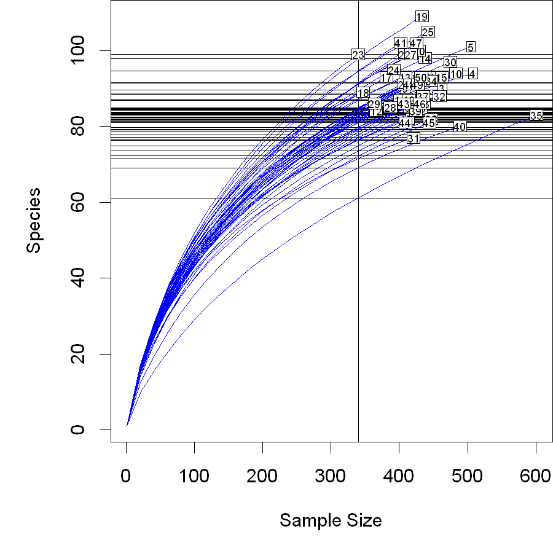

```r
par (mai=c(1,1,0,0))

Srare <- rarefy(BCI, raremax) #rarefaction
rarecurve(BCI, step = 20, sample = raremax, col = "blue", cex = 0.6)
```

I also want to show you how to run a similar analysis using the package “iNEXT”. We will use the same database, but to better visualize the results we are going to work with the first three sites of the database.

```r
require (iNEXT)

BCI_1<-as.vector (t(BCI[1,]))#site1 data
BCI_2<-as.vector (t(BCI[2,]))#site2 data
BCI_3<-as.vector (t(BCI[3,]))#site3 data

data_list <- list(BCI_1, BCI_2, BCI_3)#yeah, this is the first time that
# we are using a list! Some packages require the data to be organized
# this way.

names(data_list) <- c("Site1", "Site2", "Site3")
```

iNEXT allows us to run rarefaction analysis for richness, Shannon diversity and Simpson diversity via Hill numbers (0=richness, 1=Shannon and 2=Simpson). Besides that, the function makes predictions about the richness/diversity for larger sample sizes!

```r
iNEXT_results <- iNEXT(data_list, datatype = "abundance",
                       q=c(0,1,2),se=TRUE)
```

We can assess some details about the data using the code below.

```r
iNEXT_results$DataInfo # showing basic data information
```

| site | n | S.obs | SC | f1 | f2 | f3 | f4 | f5 | f6 | f7 | f8 | f9 | f10 |
| --- | --- | --- | --- | --- | --- | --- | --- | --- | --- | --- | --- | --- | --- |
| Site1 | 448 | 93 | 0.9310 | 31 | 18 | 9 | 6 | 6 | 4 | 1 | 1 | 1 | 1 |
| Site2 | 435 | 84 | 0.9289 | 31 | 13 | 7 | 4 | 7 | 3 | 3 | 1 | 1 | 1 |
| Site3 | 463 | 90 | 0.9202 | 37 | 12 | 10 | 5 | 3 | 5 | 3 | 1 | 1 | 1 |

```r
iNEXT_results$AsyEst # showing asymptotic diversity estimates.
```

| Site | Diversity | Observed | Estimator | s.e. | LCL | UCL |
| --- | --- | --- | --- | --- | --- | --- |
| Site1 | Species richness | 93.000 | 119.635 | 12.553 | 104.072 | 157.075 |
| Site1 | Shannon diversity | 55.613 | 64.503 | 3.500 | 57.643 | 71.363 |
| Site1 | Simpson diversity | 39.416 | 43.121 | 2.753 | 39.416 | 48.518 |
| Site2 | Species richness | 84.000 | 120.877 | 17.803 | 99.036 | 174.441 |
| Site2 | Shannon diversity | 46.921 | 54.577 | 2.998 | 48.700 | 60.454 |
| Site2 | Simpson diversity | 31.585 | 33.979 | 2.098 | 31.585 | 38.092 |
| Site3 | Species richness | 90.000 | 146.918 | 26.022 | 114.234 | 223.687 |
| Site3 | Shannon diversity | 45.334 | 53.611 | 3.447 | 46.856 | 60.366 |
| Site3 | Simpson diversity | 28.255 | 30.026 | 2.395 | 28.255 | 34.720 |

```r
head(iNEXT_results$iNextEst$Site1) # showing diversity estimates with rarefied and extrapolated
#for site 1
```

| m | method | order | qD | qD.LCL | qD.UCL | SC | SC.LCL | SC.UCL |
| --- | --- | --- | --- | --- | --- | --- | --- | --- |
| 1 | interpolated | 0 | 1.000 | 1.000 | 1.000 | 0.023 | 0.020 | 0.026 |
| 25 | interpolated | 0 | 19.528 | 18.972 | 20.084 | 0.400 | 0.366 | 0.434 |
| 50 | interpolated | 0 | 32.032 | 30.630 | 33.435 | 0.586 | 0.552 | 0.619 |
| 75 | interpolated | 0 | 41.100 | 38.938 | 43.261 | 0.684 | 0.654 | 0.713 |
| 100 | interpolated | 0 | 48.254 | 45.448 | 51.059 | 0.742 | 0.717 | 0.768 |
| 124 | interpolated | 0 | 53.983 | 50.641 | 57.324 | 0.780 | 0.757 | 0.803 |

Let’s plot the rarefaction curves

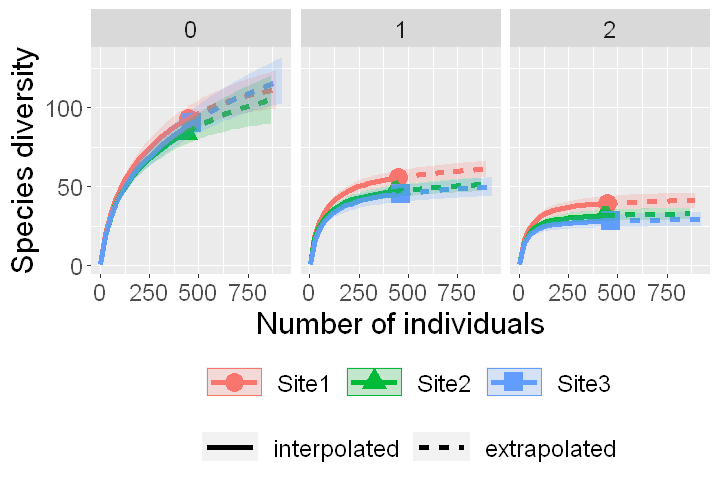

```r
ggiNEXT(iNEXT_results,type=1,facet.var="order")
```

Rather than using abundance, we can use frequency of occurrence. This is very useful when we don’t have numerical abundance data. Let’s imagine that we have three sites with 10 observation each.

```r
data (BCI)

#using the BCI to create an example!
BCI_1_pa <- t(BCI[1:10,])
BCI_2_pa <- t(BCI[11:20,])
BCI_3_pa <- t(BCI[21:30,])

BCI_1_pa <- decostand (BCI_1_pa, method="pa") #transforming to pa using vegan
BCI_2_pa <- decostand (BCI_2_pa, method="pa")
BCI_3_pa <- decostand (BCI_3_pa, method="pa")
```

Now that have the incidence data for each site, we can create the list and run the iNEXT function.

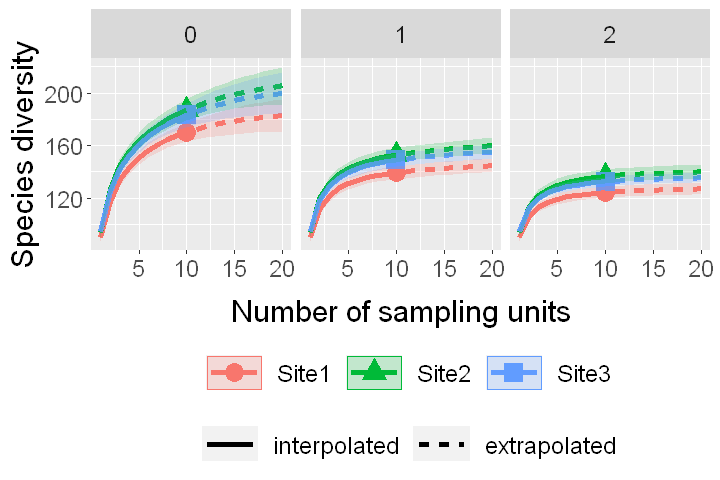

```r
data_list_pa <-list (BCI_1_pa,BCI_2_pa,BCI_3_pa)
names(data_list_pa) <- c("Site1", "Site2", "Site3")
iNEXT_results_pa <- iNEXT(data_list_pa, datatype="incidence_raw",q=c(0,1,2),se=TRUE)
                    ggiNEXT(iNEXT_results_pa,type=1,facet.var="order") #plotting
```

Return to the Summary

### Multivariate analysis of variance (MANOVA)

MANOVA is simply an ANOVA with multiple response variables. In this section, we are going to learn a MANOVA that is based on permutation tests (PERMANOVA) and do not require the assumption of multivariate normality.  
Again, let’s use data available on the package vegan.

```r
require (vegan)
data (dune)
data(dune.env)
```

The goal here is to verify if the structure of plant communities of dunes (30 species) vary according to the type of soil management (factor with four levels). To do that, we can use the function “adonis” in the package “vegan”

```r
adonis (dune~dune.env$Management)
```

```
Call:
adonis(formula = dune ~ dune.env$Management)

Permutation: free
Number of permutations: 999

Terms added sequentially (first to last)

                    Df SumsOfSqs MeanSqs F.Model      R2 Pr(>F)
dune.env$Management  3    1.4686 0.48953  2.7672 0.34161  0.001 ***
Residuals           16    2.8304 0.17690         0.65839
Total               19    4.2990                 1.00000
---
Signif. codes:  0 '***' 0.001 '**' 0.01 '*' 0.05 '.' 0.1 ' ' 1
```

Similar to an ANOVA, this analysis provide us F values, R² and a p value.

Return to the Summary

### Clusters

As the name suggest, clusters are used to organize groups according to their similarity. You need to be aware that there are many different indexes to estimate similarities and many algorithms to create clusters. In R, we can create hierarchical clusters using the function “hclust”, but before that we need to create resemble matrices:

```r
require (vegan)
data (dune)
dune.dist<-vegdist(dune,method="bray")  # resemble matrix based on bray-curtis dissimilarity
```

Now, let’s create two hierarchical clusters using two different algorithms: ward and average.

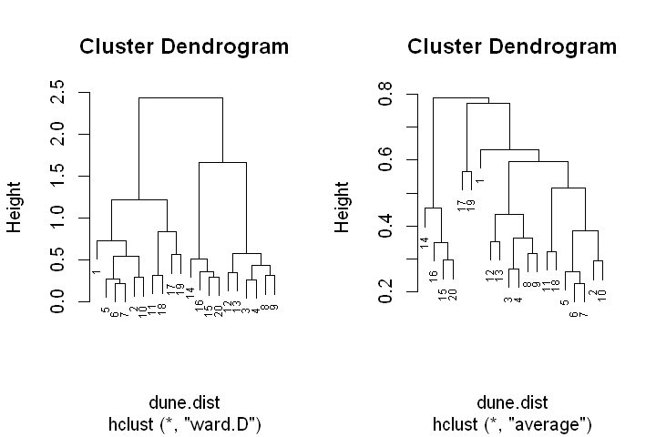

```r
par(mfrow=c(1,2))

clus_ward<-hclust(dune.dist,method="ward.D")
plot(clus_ward,cex=0.6)

clus_avg<-hclust(dune.dist,method="average")
plot(clus_avg,,cex=0.6)
```

Return to the Summary

### Unconstrained ordinations

Unconstrained ordinations are a way to reduce multiple variables into a few number of orthogonal axes that explain most part of the variation in the dataset. In order to work, the variables in the dataset must be correlated with each other, which is usually the case. Principal Component Analysis (PCA) is probably the most simple and common method of ordination. The main difference between PCA from the other ordination methods is that the PCA use exclusively the Euclidian metric to estimate the difference between sampling units. To run a PCA, we can use the function “rda” of the package vegan.

```r
require (vegan)
data(varechem) #vegan data, soil samples: physical-chemical composition

res_pca<-rda(varechem,scale=T)
# Scale=T is used to standardize (have the same
#unit of variance, mean=0 SD=1) the variables prior the analysis.
```

Let’s take a look at the results. The function summary provides many pieces of information regarding the analysis, including the importance of the components, variable coordinates (called species scores) and site coordinates (called site scores).

```r
summary(res_pca)
```

```
Call:
rda(X = varechem, scale = T)

Partitioning of correlations:
              Inertia Proportion
Total              14          1
Unconstrained      14          1

Eigenvalues, and their contribution to the correlations

Importance of components:
                         PC1    PC2    PC3     PC4     PC5     PC6     PC7
Eigenvalue            5.1916 3.1928 1.6855 1.06899 0.81599 0.70581 0.43641
Proportion Explained  0.3708 0.2281 0.1204 0.07636 0.05829 0.05042 0.03117
Cumulative Proportion 0.3708 0.5989 0.7193 0.79564 0.85392 0.90434 0.93551
                          PC8    PC9    PC10    PC11    PC12     PC13     PC14
Eigenvalue            0.36884 0.1707 0.14953 0.08526 0.06986 0.035057 0.023615
Proportion Explained  0.02635 0.0122 0.01068 0.00609 0.00499 0.002504 0.001687
Cumulative Proportion 0.96185 0.9740 0.98473 0.99082 0.99581 0.998313 1.000000

Scaling 2 for species and site scores
* Species are scaled proportional to eigenvalues
* Sites are unscaled: weighted dispersion equal on all dimensions
* General scaling constant of scores:  4.236078


Species scores

             PC1     PC2      PC3      PC4       PC5      PC6
N         0.2441  0.2516 -0.23818  0.92846 -0.359554  0.30319
P        -0.9181 -0.4194  0.13356  0.09649  0.224909  0.07938
K        -0.9369 -0.3272 -0.06261  0.25051  0.180899 -0.28683
Ca       -0.9280 -0.1711  0.47982 -0.02138 -0.241479 -0.09536
Mg       -0.9087 -0.1978  0.12446 -0.04430 -0.497428 -0.10781
S        -0.8576 -0.6002 -0.31620 -0.01652  0.071629 -0.08779
Al        0.2980 -0.9720 -0.39009  0.09092  0.005386 -0.19467
Fe        0.5236 -0.7748 -0.23063  0.37187 -0.023377 -0.32292
Mn       -0.7418  0.3908  0.13114  0.44346  0.501064  0.06776
Zn       -0.8926 -0.3277  0.06142 -0.06121 -0.153677  0.51653
Mo       -0.1072 -0.4625 -0.85720 -0.27258 -0.030063  0.39721
```

[output cut: 17 more lines]

```
13 -0.62483 -0.85407 -1.259755  1.38195 -0.157593 -1.04794
14 -0.04206  0.60916 -0.719743 -0.73109 -0.230147  0.25505
20 -0.93747  0.20753 -0.689713  0.62198 -0.282188  0.33232
25 -0.34451  0.90128  0.710714  0.64127  1.214897  0.48173
7   1.50502 -0.22114 -0.495604  0.87068 -0.769266 -0.25733
5   1.40889  0.60035  0.911463  0.71133 -0.488111  2.45195
6   1.30776  0.03604 -0.243884 -0.87792  0.543259  0.46876
3   1.64967 -0.82755 -0.343406  1.40028 -0.546374 -0.19580
4  -0.26711 -1.65198 -1.744251 -0.60763  0.947492  0.46203
2   0.59653 -1.21610 -0.200030  0.72815  0.799208 -0.76013
9   0.03271 -0.69445 -0.350028 -1.35247  0.717140  0.82965
12  0.47944  0.26377  0.184677 -1.27744  0.573929  0.07253
10 -0.32993 -0.95483  1.670469 -0.51343  0.819138 -0.48682
11 -0.09921 -1.52318  2.493913 -0.09044 -1.092296 -1.10654
21  0.49069  1.17838  0.202333 -0.73801 -1.254205 -0.85966
```

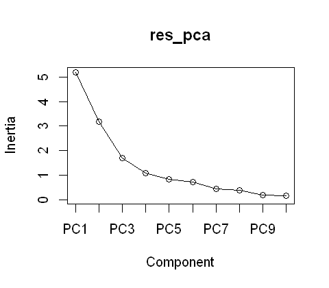

```r
screeplot(res_pca,type = "l") # scree plot
```

We can create a plot of the main axes

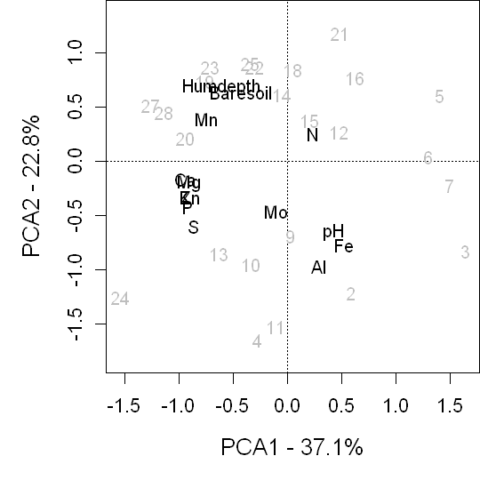

```r
par (mai=c(1,1,0,0))

plot (res_pca, xlab="PCA1 - 37.1%",ylab="PCA2 - 22.8%",
     type="n",choices=c(1,2),cex.lab=1.3,cex.axis=1.1)

text (res_pca,display="sites",
      col="88", choices = c(1, 2))

text(res_pca, display = "species",
     choices = c(1, 2))
```

Now, suppose that these sites were collected in two different periods: Dry season and wet season. The first 12 sampling units were collected during the dry season and the remain in the wet season. We can easily specify colors (or symbols) in the plot for each season. For instance:

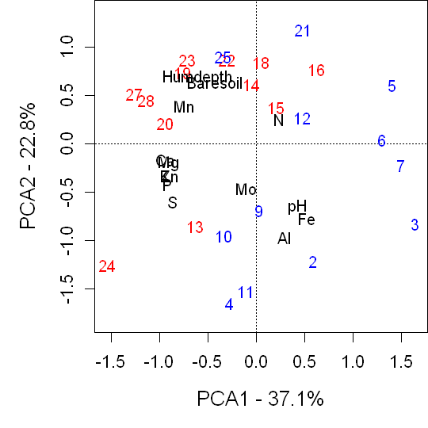

```r
par (mai=c(1,1,0,0))
plot (res_pca, xlab="PCA1 - 37.1%",ylab="PCA2 - 22.8%",
      type="n",choices=c(1,2),cex.lab=1.3,cex.axis=1.1)

text (res_pca,display="sites",col=rep(c("red","blue"),each=12),
      choices = c(1, 2))

text(res_pca, display = "species",choices = c(1, 2))
```

In some situation, we can use species and sites scores for other analyses. To extract these values from the ordination, we can use the function “scores”. For instance:

```r
scores (res_pca,display="sites")
scores (res_pca,display="species")
```

|  | PC1 | PC2 |
| --- | --- | --- |
| 18 | 0.05125774 | 0.84085141 |
| 15 | 0.20451664 | 0.37396845 |
| 24 | -1.53646532 | -1.25829807 |
| 27 | -1.25642818 | 0.51344912 |
| 23 | -0.71203013 | 0.86246533 |
| 19 | -0.76179163 | 0.73785383 |
| 22 | -0.30339881 | 0.86303581 |
| 16 | 0.62797317 | 0.76435889 |
| 28 | -1.13922500 | 0.44909361 |
| 13 | -0.62483096 | -0.85407334 |
| 14 | -0.04205762 | 0.60916369 |
| 20 | -0.93747058 | 0.20753216 |
| 25 | -0.34450969 | 0.90128283 |
| 7 | 1.50502072 | -0.22114340 |
| 5 | 1.40888836 | 0.60035498 |
| 6 | 1.30776410 | 0.03603859 |
| 3 | 1.64966903 | -0.82755080 |
| 4 | -0.26710838 | -1.65197820 |
| 2 | 0.59652585 | -1.21609676 |
| 9 | 0.03271338 | -0.69445160 |
| 12 | 0.47943679 | 0.26377399 |
| 10 | -0.32992544 | -0.95482574 |
| 11 | -0.09921276 | -1.52318433 |
| 21 | 0.49068874 | 1.17837957 |

|  | PC1 | PC2 |
| --- | --- | --- |
| N | 0.2440979 | 0.2515733 |
| P | -0.9180524 | -0.4193826 |
| K | -0.9368729 | -0.3271677 |
| Ca | -0.9280154 | -0.1710871 |
| Mg | -0.9087391 | -0.1977676 |
| S | -0.8576285 | -0.6001923 |
| Al | 0.2979981 | -0.9719998 |
| Fe | 0.5236461 | -0.7748245 |
| Mn | -0.7417951 | 0.3908124 |
| Zn | -0.8926155 | -0.3276820 |
| Mo | -0.1071693 | -0.4625158 |
| Baresoil | -0.4217537 | 0.6386581 |
| Humdepth | -0.6070224 | 0.6824708 |
| pH | 0.4285669 | -0.6517311 |

Principal Coordinates Analysis (PCoA) is an extension of the PCA and allow us to use different similarity (dissimilarity) metrics, including Bray-Curtis and Sorensen. For this analysis, we are going to use the data “varespec” of the R package “vegan”.

```r
data (varespec) # plant composition of lichen pastures
```

Let’s run the analysis (function capscale – vegan) and check the results with the summary function, which looks very similar to a PCA summary. For this example, we are going to use the Bray-Curtis dissimilarity.

```r
res_pcoa<-capscale(varespec ~1, dist="bray")
#1 is just a constant and is not constraining the results.
#“dist” specify the similarity/dissimilarity metric.
summary(res_pcoa)$cont #Importance of components
```

**$importance** =

|  | MDS1 | MDS2 | MDS3 | MDS4 | MDS5 | MDS6 | MDS7 | MDS8 | MDS9 | MDS10 | MDS11 | MDS12 | MDS13 | MDS14 | MDS15 |
| --- | --- | --- | --- | --- | --- | --- | --- | --- | --- | --- | --- | --- | --- | --- | --- |
| Eigenvalue | 1.7552165 | 1.1334455 | 0.44290185 | 0.36980543 | 0.24535315 | 0.19609208 | 0.17511309 | 0.12844667 | 0.09715944 | 0.07596007 | 0.06371779 | 0.05832251 | 0.039493379 | 0.017269924 | 0.005101108 |
| Proportion Explained | 0.3654114 | 0.2359674 | 0.09220593 | 0.07698829 | 0.05107907 | 0.04082361 | 0.03645608 | 0.02674079 | 0.02022723 | 0.01581382 | 0.01326515 | 0.01214193 | 0.008221966 | 0.003595355 | 0.001061979 |
| Cumulative Proportion | 0.3654114 | 0.6013788 | 0.69358473 | 0.77057302 | 0.82165210 | 0.86247571 | 0.89893179 | 0.92567258 | 0.94589981 | 0.96171363 | 0.97497877 | 0.98712070 | 0.995342666 | 0.998938021 | 1.000000000 |

The plot can also be generated using the function “plot”.

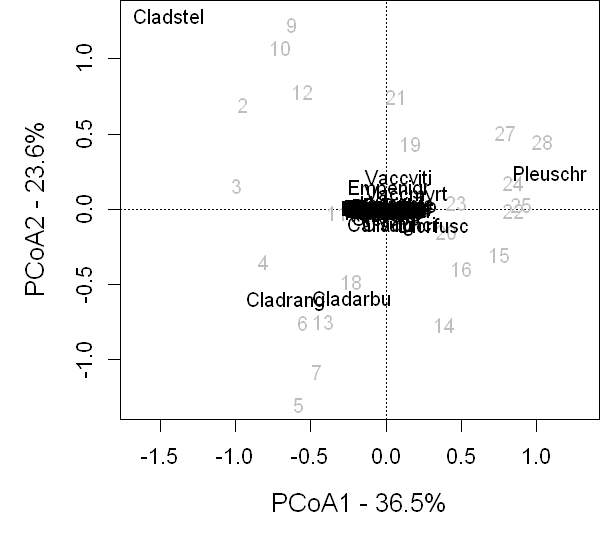

```r
par (mai=c(1,1,0,0))
plot (res_pcoa, xlab="PCoA1 - 36.5%",ylab="PCoA2 - 23.6%",
      type="n",choices=c(1,2),cex.lab=1.3,cex.axis=1.1)

text (res_pcoa,display="sites",col="88", choices = c(1, 2))
text(res_pcoa, display = "species",choices = c(1, 2))
```

Doesn’t look good, does it? In many cases, we have to log transform (or sqrt) the abundance data to improve the plots. You may also try using different ordinations, such as NMDS – our next analysis!

Non-Metric Multidimensional Scaling (NMDS) ordination is a flexible method that can accommodate different kinds of data using rank orders. Similar to a PCoA, NMDS accepts different types of similarity/dissimilarity metrics. To run a NMDS, we use the function metaMDS (Vegan package)

```r
res_nmds<-metaMDS (varespec,distance="bray",k=2) # k specify the number of dimensions created
```

```
Square root transformation
Wisconsin double standardization
*** No convergence -- monoMDS stopping criteria:
    20: stress ratio > sratmax
```

As a rule of thumb, stress values around or above 0.2 are considered suspect and values approaching 0.3 indicates that the ordination is arbitrary. Stress values lower or equal to 0.1 are considered fair and values lower or equal to 0.05 indicate good fit.

We can plot a NMDS ordination in the same way as we were doing before

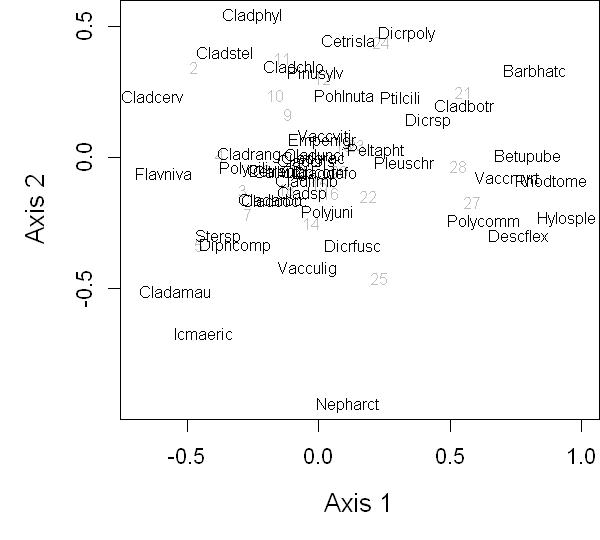

```r
par (mai=c(1,1,0,0))
plot (res_nmds, xlab="Axis 1",ylab="Axis 2",
      type="n",choices=c(1,2),cex.lab=1.3,cex.axis=1.1)

text (res_nmds,display="sites",col="88", choices = c(1, 2),cex= 0.8)
text(res_nmds, display = "species",choices = c(1, 2),cex=0.8)
```

Return to the Summary

### Constrained ordinations

The next step is constrain the ordinations by other variables. In order words, we want to verify how much of our multivariate response variable can be explained by our explanatory variables. Here, we are going to explore three main methods to do it: i) redundancy analysis (RDA), which is a constrained version of a PCA; ii) db-RDA, which is a constrained version of a PCoA; and iii) canonical correspondence analysis (CCA), which is a constrained version of a Correspondence Analysis (CA). All these analyses can be used to explore how biological communities respond to environmental variables and that’s what we are going to do here in these examples. Here, we are going to use the "varespec" and "varechem" datasets.

```r
require (vegan)

data(varespec); data (varechem) #; allows you to run multiple pieces of codes in a single row
# Plant composition and environmental variables of lichen pastures
```

To run a RDA with community data, we first need to transform our data using Hellinger transformation to avoid biases caused by some particularities of the Euclidean distance metric.

```r
varespec_trans <-decostand(varespec,method="hellinger")
```

Now, we are free to run the analysis! For this example, let’s use the first three explanatory variables.

```r
N<-varechem[,1]
P<-varechem[,2]
K<-varechem[,3]

res_rda<-rda (varespec_trans~N+P+K)
summary(res_rda) #shows you the amount of the inertia explained by the analysis,
#the amount of explanation of each axis, and the scores.
```

```
Call:
rda(formula = varespec_trans ~ N + P + K)

Partitioning of variance:
              Inertia Proportion
Total         0.36467     1.0000
Constrained   0.07372     0.2021
Unconstrained 0.29095     0.7979

Eigenvalues, and their contribution to the variance

Importance of components:
                         RDA1    RDA2    RDA3    PC1     PC2     PC3     PC4
Eigenvalue            0.03484 0.02417 0.01471 0.1275 0.05837 0.02145 0.01729
Proportion Explained  0.09553 0.06628 0.04034 0.3495 0.16005 0.05883 0.04742
Cumulative Proportion 0.09553 0.16181 0.20215 0.5516 0.71169 0.77052 0.81794
                          PC5     PC6      PC7      PC8     PC9     PC10
Eigenvalue            0.01580 0.01199 0.009349 0.007287 0.00635 0.003844
Proportion Explained  0.04333 0.03287 0.025637 0.019984 0.01741 0.010540
Cumulative Proportion 0.86127 0.89414 0.919775 0.939759 0.95717 0.967711
                          PC11     PC12     PC13     PC14      PC15      PC16
Eigenvalue            0.003224 0.001959 0.001890 0.001268 0.0009545 0.0006999
Proportion Explained  0.008841 0.005373 0.005184 0.003478 0.0026175 0.0019192
Cumulative Proportion 0.976551 0.981924 0.987108 0.990586 0.9932034 0.9951226
                           PC17      PC18      PC19      PC20
Eigenvalue            0.0006559 0.0004943 0.0003898 0.0002386
Proportion Explained  0.0017986 0.0013555 0.0010690 0.0006543
Cumulative Proportion 0.9969211 0.9982767 0.9993457 1.0000000

Accumulated constrained eigenvalues
Importance of components:
                         RDA1    RDA2    RDA3
Eigenvalue            0.03484 0.02417 0.01471
Proportion Explained  0.47259 0.32786 0.19955
Cumulative Proportion 0.47259 0.80045 1.00000

Scaling 2 for species and site scores
* Species are scaled proportional to eigenvalues
* Sites are unscaled: weighted dispersion equal on all dimensions
* General scaling constant of scores:  1.701798
```

[output cut: 100 more lines]

```
4   0.477014 -0.136220 -0.063388  0.468533  0.59625 -0.12930
2   0.044045 -0.005774 -0.051722  0.591716 -0.26490 -0.16829
9   0.072826 -0.570658 -0.148277  0.312941 -0.38087 -0.30549
12 -0.197267 -0.439257  0.329482  0.222641 -0.28196 -0.04966
10  0.466205 -0.373999  0.048686  0.525369 -0.07629 -0.14797
11  0.308817 -0.234767  0.132808  0.204281  0.26934  0.14819
21 -0.389887 -0.194956  0.219388 -0.089465 -0.80935  0.67701


Biplot scores for constraining variables

     RDA1    RDA2    RDA3 PC1 PC2 PC3
N -0.3856 0.86484 -0.3215   0   0   0
P  0.9678 0.04944 -0.2466   0   0   0
K  0.8570 0.35236  0.3761   0   0   0
```

We can test the significance of the model, the explanatory variables and the axes. Just keep in mind that sample size matter and you should have multiple sample units per variable.

```r
anova.cca (res_rda) # RDA significance
```

|  | Df | Variance | F | Pr(>F) |
| --- | --- | --- | --- | --- |
| Model | 3 | 0.07371832 | 1.689112 | 0.069 |
| Residual | 20 | 0.29095491 | NA | NA |

```r
anova.cca (res_rda, by="term") # Significance of each variable
```

|  | Df | Variance | F | Pr(>F) |
| --- | --- | --- | --- | --- |
| N | 1 | 0.02477809 | 1.703225 | 0.128 |
| P | 1 | 0.03172654 | 2.180856 | 0.061 |
| K | 1 | 0.01721369 | 1.183255 | 0.313 |
| Residual | 20 | 0.29095491 | NA | NA |

```r
anova.cca (res_rda, by="axis") # Significance of each axis
```

|  | Df | Variance | F | Pr(>F) |
| --- | --- | --- | --- | --- |
| RDA1 | 1 | 0.03483875 | 2.394787 | 0.228 |
| RDA2 | 1 | 0.02416938 | 1.661383 | 0.318 |
| RDA3 | 1 | 0.01471020 | 1.011167 | 0.375 |
| Residual | 20 | 0.29095491 | NA | NA |

We can plot the results now.

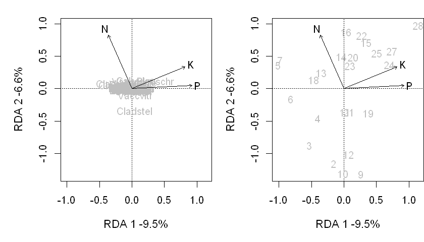

```r
options(repr.plot.width=7, repr.plot.height=4, repr.plot.res = 120,
       repr.plot.quality=600)

par (mfrow=c(1,2),mai=c(1,1,0.3,0))
#focusing on the species
plot (res_rda, xlab="RDA 1 -9.5%",ylab="RDA 2 -6.6%",
      type="n",choices=c(1,2),cex.lab=1.1,cex.axis=1)
text (res_rda,display="species",col="88", choices = c(1, 2))
text(res_rda, display = "bp")
#focusing on the sites
plot (res_rda, xlab="RDA 1 -9.5%",ylab="RDA 2 -6.6%",
      type="n",choices=c(1,2),cex.lab=1.1,cex.axis=1)
text (res_rda,display="sites",col="88", choices = c(1, 2))
text(res_rda, display = "bp")
```

To run a db-RDA, we can use the same “capscale” function that we used for the PCoA analysis.

```r
res_pcoa <-capscale(varespec ~ N+P+K, dist="bray")
```

Let’s check the main results.

```r
summary(res_pcoa)$cont
```

**$importance** =

|  | CAP1 | CAP2 | CAP3 | MDS1 | MDS2 | MDS3 | MDS4 | MDS5 | MDS6 | MDS7 | MDS8 | MDS9 | MDS10 | MDS11 | MDS12 | MDS13 | MDS14 | MDS15 |
| --- | --- | --- | --- | --- | --- | --- | --- | --- | --- | --- | --- | --- | --- | --- | --- | --- | --- | --- |
| Eigenvalue | 0.4953195 | 0.28466890 | 0.13393208 | 1.5374996 | 0.8007924 | 0.39990568 | 0.29769855 | 0.20369878 | 0.16291390 | 0.14250694 | 0.09690412 | 0.07491221 | 0.05881562 | 0.05117319 | 0.030515822 | 0.021203772 | 0.009252276 | 0.0016852906 |
| Proportion Explained | 0.1031185 | 0.05926406 | 0.02788278 | 0.3200858 | 0.1667137 | 0.08325474 | 0.06197665 | 0.04240722 | 0.03391638 | 0.02966794 | 0.02017407 | 0.01559567 | 0.01224458 | 0.01065354 | 0.006352965 | 0.004414327 | 0.001926194 | 0.0003508538 |
| Cumulative Proportion | 0.1031185 | 0.16238261 | 0.19026538 | 0.5103512 | 0.6770649 | 0.76031960 | 0.82229625 | 0.86470347 | 0.89861986 | 0.92828780 | 0.94846187 | 0.96405754 | 0.97630212 | 0.98695566 | 0.993308626 | 0.997722953 | 0.999649146 | 1.0000000000 |

```r
anova.cca(res_pcoa)
```

|  | Df | SumOfSqs | F | Pr(>F) |
| --- | --- | --- | --- | --- |
| Model | 3 | 0.9139205 | 1.566483 | 0.076 |
| Residual | 20 | 3.8894781 | NA | NA |

```r
anova.cca(res_pcoa, by="terms")
```

|  | Df | SumOfSqs | F | Pr(>F) |
| --- | --- | --- | --- | --- |
| N | 1 | 0.3524324 | 1.8122349 | 0.095 |
| P | 1 | 0.3937811 | 2.0248530 | 0.068 |
| K | 1 | 0.1677070 | 0.8623625 | 0.553 |
| Residual | 20 | 3.8894781 | NA | NA |

```r
anova.cca(res_pcoa, by="axis")
```

|  | Df | SumOfSqs | F | Pr(>F) |
| --- | --- | --- | --- | --- |
| CAP1 | 1 | 0.4953195 | 2.5469714 | 0.182 |
| CAP2 | 1 | 0.2846689 | 1.4637897 | 0.418 |
| CAP3 | 1 | 0.1339321 | 0.6886892 | 0.660 |
| Residual | 20 | 3.8894781 | NA | NA |

Now, let's plot the results.

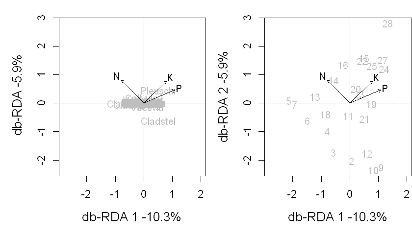

```r
par (mfrow=c(1,2),mai=c(1,1,0.3,0))
#focusing on the species
plot (res_pcoa, xlab="db-RDA 1 -10.3%",ylab=" db-RDA -5.9%",
      type="n",choices=c(1,2),cex.lab=1.3,cex.axis=1.1)
text (res_pcoa,display="species",col="88", choices = c(1, 2))
text(res_pcoa, display = "bp")

#focusing on the sites
plot (res_pcoa, xlab="db-RDA 1 -10.3%",ylab="db-RDA 2 -5.9%",
      type="n",choices=c(1,2),cex.lab=1.3,cex.axis=1.1)
text (res_pcoa,display="sites",col="88", choices = c(1, 2))
text(res_pcoa, display = "bp")
```

Finally, we will conduct a “cca”, which, again, is not much different (in terms of coding) from what we have already done. CCA is based on the chi-square distance and in many cases, tend to be sensitive to the presence of rare species.

```r
res_cca <- cca (varespec ~ N+P+K)
summary (res_cca)$cont
```

**$importance** =

|  | CCA1 | CCA2 | CCA3 | CA1 | CA2 | CA3 | CA4 | CA5 | CA6 | CA7 | ... | CA11 | CA12 | CA13 | CA14 | CA15 | CA16 | CA17 | CA18 | CA19 | CA20 |
| --- | --- | --- | --- | --- | --- | --- | --- | --- | --- | --- | --- | --- | --- | --- | --- | --- | --- | --- | --- | --- | --- |
| Eigenvalue | 0.19308594 | 0.16271109 | 0.09060228 | 0.4495311 | 0.2870118 | 0.18771602 | 0.16748246 | 0.12804765 | 0.10496774 | 0.07497171 | ... | 0.02524980 | 0.01903756 | 0.013120301 | 0.012103107 | 0.007760421 | 0.005248734 | 0.003723464 | 0.002849447 | 0.0019281278 | 0.0005383818 |
| Proportion Explained | 0.09268726 | 0.07810639 | 0.04349191 | 0.2157889 | 0.1377746 | 0.09010953 | 0.08039679 | 0.06146686 | 0.05038778 | 0.03598875 | ... | 0.01212069 | 0.00913862 | 0.006298153 | 0.005809868 | 0.003725244 | 0.002519555 | 0.001787379 | 0.001367823 | 0.0009255613 | 0.0002584400 |
| Cumulative Proportion | 0.09268726 | 0.17079365 | 0.21428556 | 0.4300745 | 0.5678491 | 0.65795860 | 0.73835539 | 0.79982225 | 0.85021003 | 0.88619878 | ... | 0.96816936 | 0.97730798 | 0.983606130 | 0.989415998 | 0.993141241 | 0.995660797 | 0.997448175 | 0.998815999 | 0.9997415600 | 1.0000000000 |

```r
anova.cca(res_cca)
```

|  | Df | ChiSquare | F | Pr(>F) |
| --- | --- | --- | --- | --- |
| Model | 3 | 0.4463993 | 1.81818 | 0.011 |
| Residual | 20 | 1.6367990 | NA | NA |

```r
anova.cca(res_cca, by="terms")
```

|  | Df | ChiSquare | F | Pr(>F) |
| --- | --- | --- | --- | --- |
| N | 1 | 0.1300084 | 1.588569 | 0.113 |
| P | 1 | 0.1799622 | 2.198953 | 0.015 |
| K | 1 | 0.1364287 | 1.667018 | 0.126 |
| Residual | 20 | 1.6367990 | NA | NA |

```r
anova.cca(res_cca, by="axis")
```

|  | Df | ChiSquare | F | Pr(>F) |
| --- | --- | --- | --- | --- |
| CCA1 | 1 | 0.19308594 | 2.359312 | 0.107 |
| CCA2 | 1 | 0.16271109 | 1.988162 | 0.137 |
| CCA3 | 1 | 0.09060228 | 1.107067 | 0.357 |
| Residual | 20 | 1.63679898 | NA | NA |

Now we can plot the results.

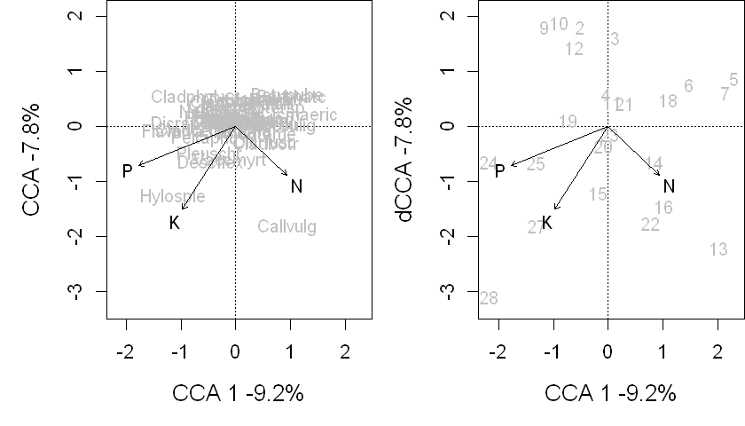

```r
par (mfrow=c(1,2),mai=c(1,1,0,0))

# focusing on the species
plot (res_cca, xlab="CCA 1 -9.2%",ylab="CCA -7.8%",
      type="n",choices=c(1,2),cex.lab=1.3,cex.axis=1.1)
text (res_cca,display="species",col="88", choices = c(1, 2))
text(res_cca, display = "bp")

#focusing on the sites
plot (res_cca, xlab="CCA 1 -9.2%",ylab="dCCA -7.8%",
      type="n",choices=c(1,2),cex.lab=1.3,cex.axis=1.1)

text (res_cca,display="sites",col="88", choices = c(1, 2))
text(res_cca, display = "bp")
```

Return to the Summary

## Occupancy modeling

The main goal of occupancy analysis is to account for imperfect detection of organisms and estimate the probability of the presence/absence of a given species at a given site or estimate the percentage of sites that are occupied by this species. This type of analysis also allows you to test variables related with detection and occupancy. Occupancy models were first introduced by MacKenzie et al. 2002 and Tyre et al. 2003 and I strongly suggest you read these sources if you are interested to apply this type of analysis in your study.  
In order to estimate probability of occupancy (Ψ) and detection (p), multiple visits should be conducted at each site and some assumptions have to be made (MacKenzie et al. 2002):

1. Occupancy state of the sites does not change during the period of surveying;
2. Detection process is independent at each site;
3. Probability of detection is constant across sites and visits or explained by covariates;
4. Probability of occupancy is constant across sites or explained by covariates.

The input data used in occupancy analysis can be classified into three categories:

1. **Detection histories** - rows of the data represent sites and the columns represent multiple observations.
2. **Site-specific covariates** - Variables measured on each of the sites that may explain site-by-site variability in detection and/or occupancy.
3. **Sample-specific or "observation level" covariates**: Variables measured at each of the observations (replicates).

Here, we are going to use the unmarked package to model the probability of occurence and detection of Blue grosbeak (blgr data). This example was taking from this [website](https://sites.google.com/site/asrworkshop/home/schedule/r-occupancy-1) created by Nathan J. Hostetter. First, load the package and the blgr data.

```r
require (unmarked)
blgr <- read.csv ('blgr.csv',header=T,sep=';')
head(blgr)
```

A data.frame: 6 × 10

|  | field <int> | y.1 <int> | y.2 <int> | y.3 <int> | field.size <dbl> | bqi <int> | crop.hist <chr> | t1 <int> | t2 <int> | t3 <int> |
| --- | --- | --- | --- | --- | --- | --- | --- | --- | --- | --- |
| 1 | 1 | 1 | 1 | 1 | 14.0 | 1 | crop | 1 | 2 | 3 |
| 2 | 2 | 1 | 1 | 0 | 12.7 | 1 | crop | 1 | 2 | 3 |
| 3 | 3 | 0 | 0 | 0 | 15.7 | 0 | grass | 1 | 2 | 3 |
| 4 | 4 | 0 | 1 | 0 | 19.5 | 0 | grass | 1 | 2 | 3 |
| 5 | 5 | 1 | 0 | 1 | 13.5 | 0 | crop | 1 | 2 | 3 |
| 6 | 6 | 0 | 0 | 1 | 9.6 | 0 | NA | 1 | 2 | 3 |

We can now separate the data into detection histories, site-specific covariates, and sample-specific covariates.

```r
#detection histories
y<- blgr[,2:4]

#site level (individual) covariates
blgr.site<- blgr[,5:9]

#sample-specific covariates
blgr <-within (blgr,{
  t1 <- factor (t1)
  t2 <- factor (t2)
  t3 <- factor (t3)
}) #Make sure that each replicate is considered as a category level
blgr.obs <- list(time=blgr[,c("t1", "t2", "t3")])

#number of sites
n <- nrow (blgr)
```

Before starting the analysis, we have to format the data using the function unmarkedFrameOccu. This function creates an object that can be read by other functions of the unmarked package.

```r
blgr_unmarked <- unmarkedFrameOccu(y = y, siteCovs = blgr.site,obsCovs=blgr.obs)
summary(blgr_unmarked)
```

```
unmarkedFrame Object

41 sites
Maximum number of observations per site: 3
Mean number of observations per site: 3
Sites with at least one detection: 33

Tabulation of y observations:
 0  1
63 60

Site-level covariates:
   field.size         bqi          crop.hist               t1          t2
 Min.   : 6.40   Min.   :0.0000   Length:41          Min.   :1   Min.   :2
 1st Qu.: 9.60   1st Qu.:0.0000   Class :character   1st Qu.:1   1st Qu.:2
 Median :12.70   Median :0.0000   Mode  :character   Median :1   Median :2
 Mean   :16.16   Mean   :0.3415                      Mean   :1   Mean   :2
 3rd Qu.:18.80   3rd Qu.:1.0000                      3rd Qu.:1   3rd Qu.:2
 Max.   :53.90   Max.   :1.0000                      Max.   :1   Max.   :2

Observation-level covariates:
     time
 Length:123
 Class :character
 Mode  :character
```

Now we can start modelling the data using the function "occ". The main arguments of the function are:  
occu (~detection_formula ~occupancy_formula, data)  
First, we are going to create a model with no covariates that assumes constant detection and occupancy.

```r
fm1<-occu(~1 ~1, blgr_unmarked)
fm1
```

```
Call:
occu(formula = ~1 ~ 1, data = blgr_unmarked)

Occupancy:
 Estimate    SE    z P(>|z|)
     2.04 0.751 2.71 0.00666

Detection:
 Estimate    SE     z P(>|z|)
    0.206 0.242 0.851   0.395

AIC: 172.1898
```

The function provide us parameter estimates and the AIC values. However, estimates are on the logit scale. We can convert logit scale to real scale estimations using the function backTransform. See below.

```r
backTransform(fm1,'det') #detection
```

```
Backtransformed linear combination(s) of Detection estimate(s)

 Estimate     SE LinComb (Intercept)
    0.551 0.0599   0.206           1

Transformation: logistic
```

```r
backTransform(fm1,"state") #occupancy
```

```
Backtransformed linear combination(s) of Occupancy estimate(s)

 Estimate     SE LinComb (Intercept)
    0.885 0.0766    2.04           1

Transformation: logistic
```

We can calculate the probability of occupancy of each site using the function "ranef".

```r
re <- ranef (fm1)
re
```

```
           Mean Mode 2.5% 97.5%
 [1,] 1.0000000    1    1     1
 [2,] 1.0000000    1    1     1
 [3,] 0.4095987    0    0     1
 [4,] 1.0000000    1    1     1
 [5,] 1.0000000    1    1     1
 [6,] 1.0000000    1    1     1
 [7,] 1.0000000    1    1     1
 [8,] 1.0000000    1    1     1
 [9,] 1.0000000    1    1     1
[10,] 1.0000000    1    1     1
[11,] 1.0000000    1    1     1
[12,] 0.4095987    0    0     1
[13,] 0.4095987    0    0     1
[14,] 1.0000000    1    1     1
```

[output cut: 27 more lines]

Let's create credible intervals for our occupancy estimate

```r
EBUP <- bup(re, stat="mode")
CI <- confint(re, level=0.95)

print("95 % EB interval on number sites occupied")
rbind(s_occup = c(Estimate = sum(EBUP), colSums(CI)))
```

```
[1] "95 % EB interval on number sites occupied"
```

A matrix: 1 × 3 of type dbl

|  | Estimate | 2.5% | 97.5% |
| --- | --- | --- | --- |
| s_occup | 33 | 33 | 41 |

```r
print("95 % EB interval on proportion of sites occupied")
rbind(PAO = c(Estimate = sum(EBUP), colSums(CI))/n )
```

```
[1] "95 % EB interval on proportion of sites occupied"
```

A matrix: 1 × 3 of type dbl

|  | Estimate | 2.5% | 97.5% |
| --- | --- | --- | --- |
| PAO | 0.804878 | 0.804878 | 1 |

The next step is to add covariates to detection and occupancy modeling

```r
#time specific detection, constant occupancy
fm2<-occu(~time ~1, blgr_unmarked)

#constant detection, occupancy predicted by bqi
fm3<-occu(~1 ~bqi, blgr_unmarked)

#time specific detection, occupancy predicted by bqi
fm4<-occu(~time ~bqi, blgr_unmarked)

#constant detection, occupancy predicted by log(field size)
fm5<-occu(~1 ~log(field.size), blgr_unmarked)

#constant detection, occupancy predicted by log(field size)+bqi
fm6<-occu(~1 ~log(field.size)+bqi, blgr_unmarked)
fm6 # checking result of model fm6
```

```
Call:
occu(formula = ~1 ~ log(field.size) + bqi, data = blgr_unmarked)

Occupancy:
                Estimate   SE       z P(>|z|)
(Intercept)        2.893 2.75  1.0501   0.294
log(field.size)   -0.101 1.16 -0.0867   0.931
bqi               -1.316 1.70 -0.7728   0.440

Detection:
 Estimate    SE     z P(>|z|)
    0.211 0.247 0.856   0.392

AIC: 175.1138
```

We can compare these models using AIC

```r
fmlist<-fitList(fm1,fm2,fm3,fm4,fm5,fm6)
modSel(fmlist)
```

```
    nPars    AIC delta AICwt cumltvWt
fm1     2 172.19  0.00 0.381     0.38
fm3     3 173.12  0.93 0.239     0.62
fm5     3 173.92  1.73 0.160     0.78
fm6     4 175.11  2.92 0.088     0.87
fm2     4 175.30  3.11 0.081     0.95
fm4     5 176.23  4.04 0.051     1.00
```

Converting logit scale estimates to real scale estimates is a little different when models include co-variables. In this case, we need to specify values for co-variables before estimating either detection or occupancy. Ex:

```r
lc <- linearComb(fm2, c(1, 0, 0), type="det") #Estimating detection for observation 1
backTransform(lc)
```

```
Backtransformed linear combination(s) of Detection estimate(s)

 Estimate     SE LinComb (Intercept) time2 time3
    0.497 0.0892 -0.0106           1     0     0

Transformation: logistic
```

```r
backTransform(fm2, 'state') # since we don't have co-variables in the occupancy formula, we
#don't need to especify values with the "linearComb" function
```

```
Backtransformed linear combination(s) of Occupancy estimate(s)

 Estimate     SE LinComb (Intercept)
    0.883 0.0762    2.02           1

Transformation: logistic
```

Return to the Summary

## Species distribution modeling

Species distribution models (SDMs) are very popular tools in macroecology, biogeography and biodiversity research for modelling the geographic distribution of species based on the correlation between environmental variables and occurrence/abundance data. They are often used to gain ecological and evolutionary insights and to extrapolate the distribution of species across space and time. Please, be aware that SDMs are based on important assumptions and there are intense discussions about the accuracy of model predictions. Therefore, read text books about this type of analysis (e.g., Franklin 2010) is essential before start using them. Here, we are going to create a very simplistic SDM (climate-envelope-model) of the ocurrence of a turtle using data from scientific collections. This example was based on the code provided by [Justin Waraniak](https://www.youtube.com/watch?v=1C1zVJO-Rk0) and [Jeff Oliver](https://jcoliver.github.io/learn-r/011-species-distribution-models.html). Please, install and load the packages maptools, rgeos, raster, rgdal, dismo, and rvertnet.

```r
#install.packages (c('maptools','rgeos','raster','dismo','rvertnet'))
require (maptools)
require (rgeos)
require (raster)
require (dismo)
require (rvertnet)
```

For this example, we are going to download all presence data available for the Blanding's turtle (Emydoidea blandingii) from vertnet (NSF-funded collaborative project that makes biodiversity data free and available on the web).

```r
turtle_data<- searchbyterm (scientificname="emydoidea blandingii", limit=10000)
turtle_data <- turtle_data[[2]]
```

[output not shown]

Now, let's download world boarder data available from the package maptools

```r
data ('wrld_simpl')
```

Now, we can plot the occurence data.

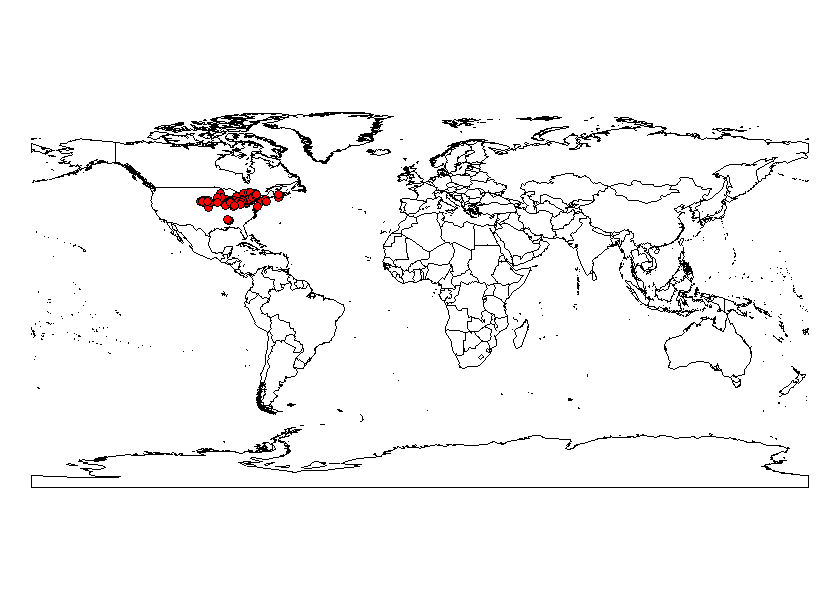

```r
plot (wrld_simpl)
points (turtle_data$decimallongitude,
        turtle_data$decimallatitude, pch=21,
        bg='red')
```

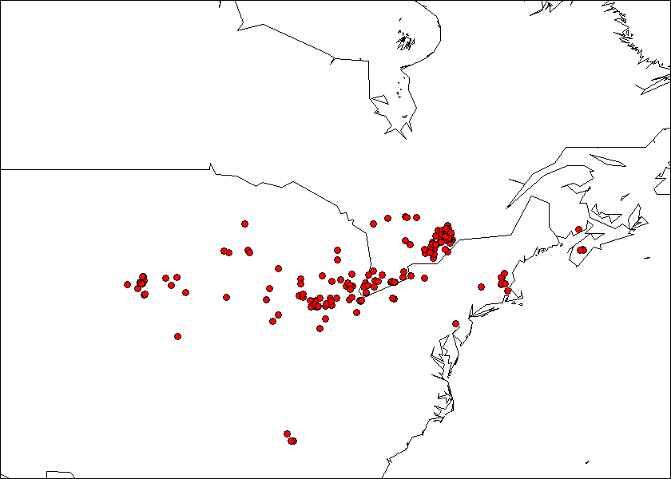

```r
#zoom in
plot (wrld_simpl, ylim =c(35,55), xlim=c(-110,-60),axes=T)
points (turtle_data$decimallongitude,
        turtle_data$decimallatitude, pch=21,
        bg='red')
```

Data needs to me clean and processed before we start the analysis.

```r
#remove NA data
turtle_data <- turtle_data[complete.cases(turtle_data$decimallongitude),]
turtle_data <- turtle_data[complete.cases(turtle_data$decimallatitude),]
nrow (turtle_data)
```

315

```r
#remove duplicates
dups <- duplicated (turtle_data[,c("decimallongitude","decimallatitude")])
turtle_data <- turtle_data [!dups,]
nrow(turtle_data)
```

205

```r
#convert lat/long to values
turtle_data <- within (turtle_data,{
  decimallongitude <- as.numeric (as.character (decimallongitude))
  decimallatitude <- as.numeric (as.character (decimallatitude))
})
```

Bioclimatic data is available from the website WorldClim. We can use R package raster to download the data.

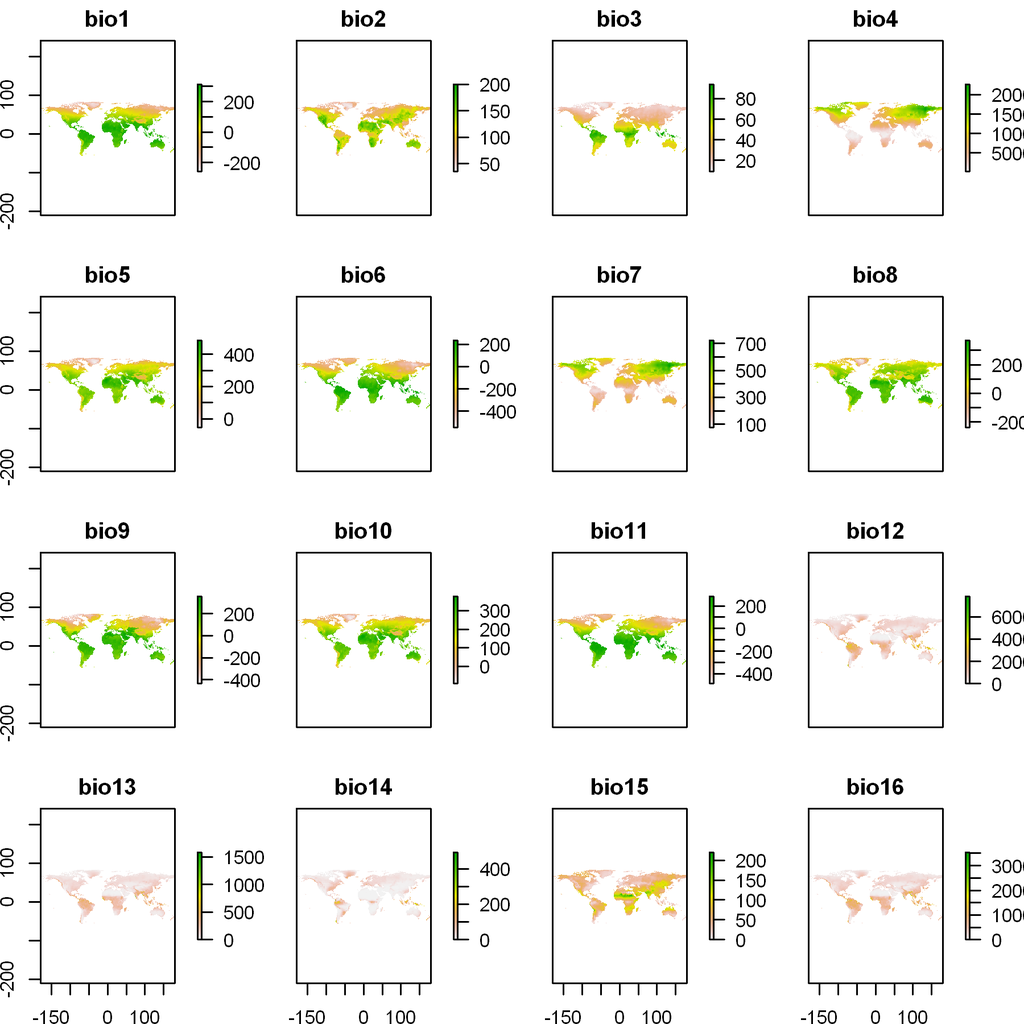

```r
#climate <- getData ('worldclim',download=T, var="bio",res=2.5)
#or load (climate.RData)
plot (climate)
```

Let's extract climate data for each one of the sites available in our database.

```r
obsclim <- extract (climate, turtle_data[,c("decimallongitude","decimallatitude")])
```

Everything that everything is set, we can create our climate-envelope-model.

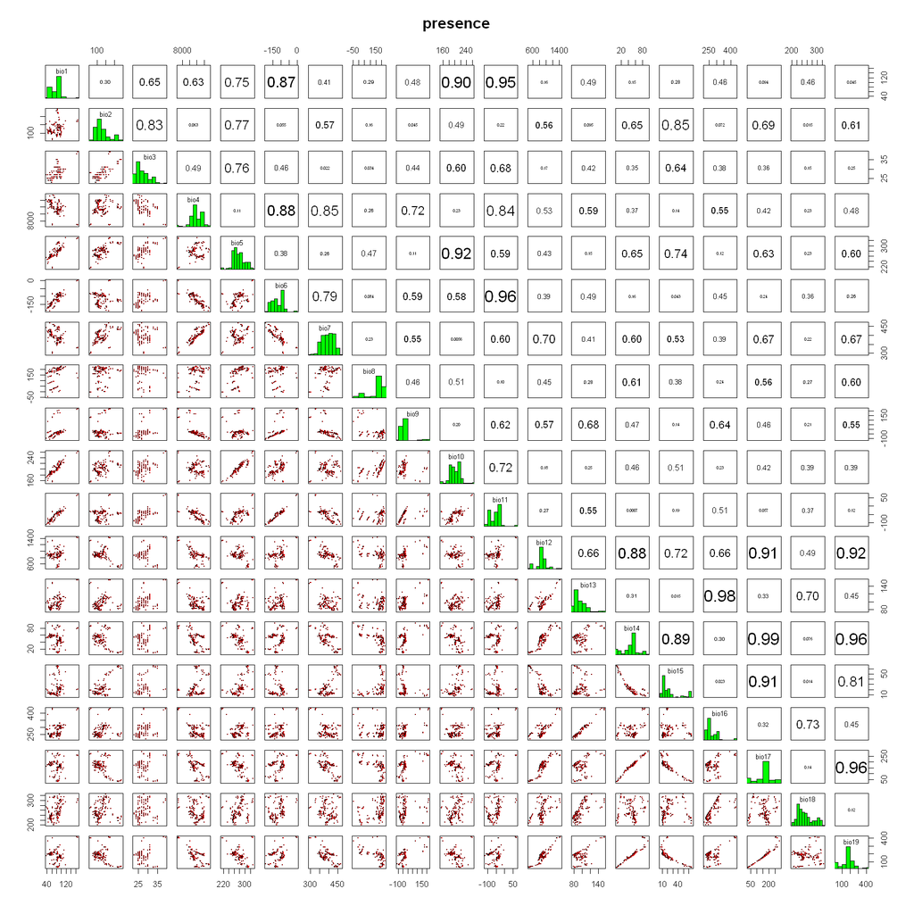

```r
turtle_model<- bioclim (obsclim) #species distribution model
pairs (turtle_model, pa='p')
# Association between environmental variables and the species occurence.
```

Let's make predictions based on our model and plot the data

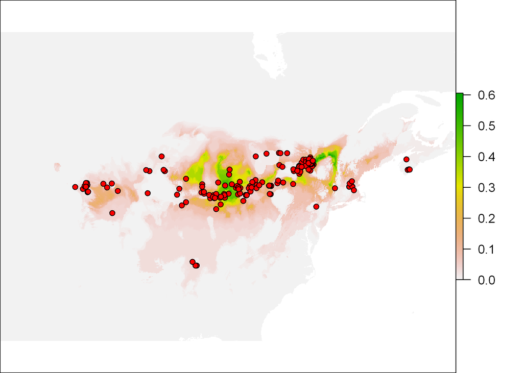

```r
predictors <- stack (climate) # raster set of predictors
predictions <- predict (predictors, turtle_model) # raster of predictions

plot (predictions,  axes=T,
      ylim =c(30,55), xlim=c(-110,-60))
points (turtle_data$decimallongitude,
        turtle_data$decimallatitude, pch=21,
        bg='red')
```

Return to the Summary